# Camara_Vogt_Project

Johnny Vogt

2025-09-24

#Library and ENV Variables

##Libraries

##Importing the Data

##Cleaning the Data Number of Door (impute) Engine HP (impute) Engine Cylinder (impute) Market Category (Has N/A, but keeping them as a category )

Will need to create another model without outliers

#EDA ##Data Summary and Early Relationship

```r
#Stats on Missing data
na_rows <- auto %>% filter(if_any(everything(), is.na))
n_removed <- nrow(na_rows)
cat("Rows removed due to NA:", n_removed, "\n")
```

```
## Rows removed due to NA: 99
```

```r
summary(na_rows)
```

```
##       MSRP            Make                Year      Engine.Fuel.Type
##  Min.   :  7523   Length:99          Min.   :1993   Length:99
##  1st Qu.: 29065   Class :character   1st Qu.:2011   Class :character
##  Median : 33950   Mode  :character   Median :2015   Mode  :character
##  Mean   : 45413                      Mean   :2013
##  3rd Qu.: 49800                      3rd Qu.:2016
##  Max.   :295000                      Max.   :2017
##
##    Engine.HP     Engine.Cylinders Transmission.Type  Driven_Wheels
##  Min.   : 66.0   Min.   : 0.000   Length:99          Length:99
##  1st Qu.:200.0   1st Qu.: 0.000   Class :character   Class :character
##  Median :212.0   Median : 0.000   Mode  :character   Mode  :character
##  Mean   :212.2   Mean   : 2.087
##  3rd Qu.:232.0   3rd Qu.: 4.000
##  Max.   :651.0   Max.   :12.000
##  NA's   :69      NA's   :30
##  Number.of.Doors Market.Category    Vehicle.Size       Vehicle.Style
##  Min.   :2.000   Length:99          Length:99          Length:99
##  1st Qu.:4.000   Class :character   Class :character   Class :character
##  Median :4.000   Mode  :character   Mode  :character   Mode  :character
##  Mean   :3.871
##  3rd Qu.:4.000
##  Max.   :4.000
##  NA's   :6
##   highway.MPG        city.mpg
##  Min.   : 16.00   Min.   : 11.00
##  1st Qu.: 23.00   1st Qu.: 16.00
##  Median : 90.00   Median : 86.00
##  Mean   : 64.45   Mean   : 68.15
##  3rd Qu.:101.00   3rd Qu.:120.00
##  Max.   :110.00   Max.   :132.00
##
```

```r
skim(na_rows)
```

Data summary

| Name | na_rows |
| --- | --- |
| Number of rows | 99 |
| Number of columns | 14 |
| _______________________ |  |
| Column type frequency: |  |
| character | 7 |
| numeric | 7 |
| ________________________ |  |
| Group variables | None |

**Variable type: character**

| skim_variable | n_missing | complete_rate | min | max | empty | n_unique | whitespace |
| --- | --- | --- | --- | --- | --- | --- | --- |
| Make | 0 | 1 | 3 | 13 | 0 | 14 | 0 |
| Engine.Fuel.Type | 0 | 1 | 6 | 32 | 0 | 6 | 0 |
| Transmission.Type | 0 | 1 | 6 | 16 | 0 | 4 | 0 |
| Driven_Wheels | 0 | 1 | 15 | 17 | 0 | 3 | 0 |
| Market.Category | 0 | 1 | 3 | 25 | 0 | 11 | 0 |
| Vehicle.Size | 0 | 1 | 5 | 7 | 0 | 3 | 0 |
| Vehicle.Style | 0 | 1 | 5 | 17 | 0 | 8 | 0 |

**Variable type: numeric**

| skim_variable | n_missing | complete_rate | mean | sd | p0 | p25 | p50 | p75 | p100 | hist |
| --- | --- | --- | --- | --- | --- | --- | --- | --- | --- | --- |
| MSRP | 0 | 1.00 | 45412.57 | 34387.51 | 7523 | 29065 | 33950 | 49800 | 295000 | ▇▂▁▁▁ |
| Year | 0 | 1.00 | 2013.29 | 4.76 | 1993 | 2011 | 2015 | 2016 | 2017 | ▁▁▁▂▇ |
| Engine.HP | 69 | 0.30 | 212.20 | 99.34 | 66 | 200 | 212 | 232 | 651 | ▂▇▁▁▁ |
| Engine.Cylinders | 30 | 0.70 | 2.09 | 2.88 | 0 | 0 | 0 | 4 | 12 | ▇▂▃▁▁ |
| Number.of.Doors | 6 | 0.94 | 3.87 | 0.49 | 2 | 4 | 4 | 4 | 4 | ▁▁▁▁▇ |
| highway.MPG | 0 | 1.00 | 64.45 | 37.61 | 16 | 23 | 90 | 101 | 110 | ▇▁▁▁▇ |
| city.mpg | 0 | 1.00 | 68.15 | 47.92 | 11 | 16 | 86 | 120 | 132 | ▇▁▁▃▆ |

```r
skimr::skim(auto_omit)
```

Data summary

| Name | auto_omit |
| --- | --- |
| Number of rows | 11815 |
| Number of columns | 15 |
| _______________________ |  |
| Column type frequency: |  |
| character | 1 |
| factor | 7 |
| numeric | 7 |
| ________________________ |  |
| Group variables | None |

**Variable type: character**

| skim_variable | n_missing | complete_rate | min | max | empty | n_unique | whitespace |
| --- | --- | --- | --- | --- | --- | --- | --- |
| Driven_Wheels | 0 | 1 | 15 | 17 | 0 | 4 | 0 |

**Variable type: factor**

| skim_variable | n_missing | complete_rate | ordered | n_unique | top_counts |
| --- | --- | --- | --- | --- | --- |
| Make | 0 | 1 | FALSE | 47 | Che: 1115, For: 868, Vol: 805, Toy: 743 |
| Engine.Fuel.Type | 0 | 1 | FALSE | 10 | reg: 7155, pre: 1991, pre: 1519, fle: 899 |
| Transmission.Type | 0 | 1 | FALSE | 5 | AUT: 8234, MAN: 2922, AUT: 625, UNK: 19 |
| Market.Category | 0 | 1 | FALSE | 71 | N/A: 3731, Cro: 1103, Fle: 872, Lux: 851 |
| Vehicle.Size | 0 | 1 | FALSE | 3 | Com: 4708, Mid: 4359, Lar: 2748 |
| Vehicle.Style | 0 | 1 | FALSE | 16 | Sed: 3016, 4dr: 2480, Cou: 1190, Con: 793 |
| MPG_bin | 10 | 1 | FALSE | 6 | 15-: 4936, <15: 2938, 20-: 2677, 25-: 883 |

**Variable type: numeric**

| skim_variable | n_missing | complete_rate | mean | sd | p0 | p25 | p50 | p75 | p100 | hist |
| --- | --- | --- | --- | --- | --- | --- | --- | --- | --- | --- |
| MSRP | 0 | 1 | 40554.37 | 60277.50 | 2000 | 20990 | 29960 | 42200 | 2065902 | ▇▁▁▁▁ |
| Year | 0 | 1 | 2010.36 | 7.59 | 1990 | 2007 | 2015 | 2016 | 2017 | ▁▁▂▂▇ |
| Engine.HP | 0 | 1 | 249.48 | 109.20 | 55 | 170 | 227 | 300 | 1001 | ▇▆▁▁▁ |
| Engine.Cylinders | 0 | 1 | 5.65 | 1.75 | 0 | 4 | 6 | 6 | 16 | ▁▇▂▁▁ |
| Number.of.Doors | 0 | 1 | 3.43 | 0.88 | 2 | 2 | 4 | 4 | 4 | ▃▁▁▁▇ |
| highway.MPG | 0 | 1 | 26.32 | 7.44 | 12 | 22 | 26 | 30 | 354 | ▇▁▁▁▁ |
| city.mpg | 0 | 1 | 19.33 | 6.53 | 7 | 16 | 18 | 22 | 137 | ▇▁▁▁▁ |

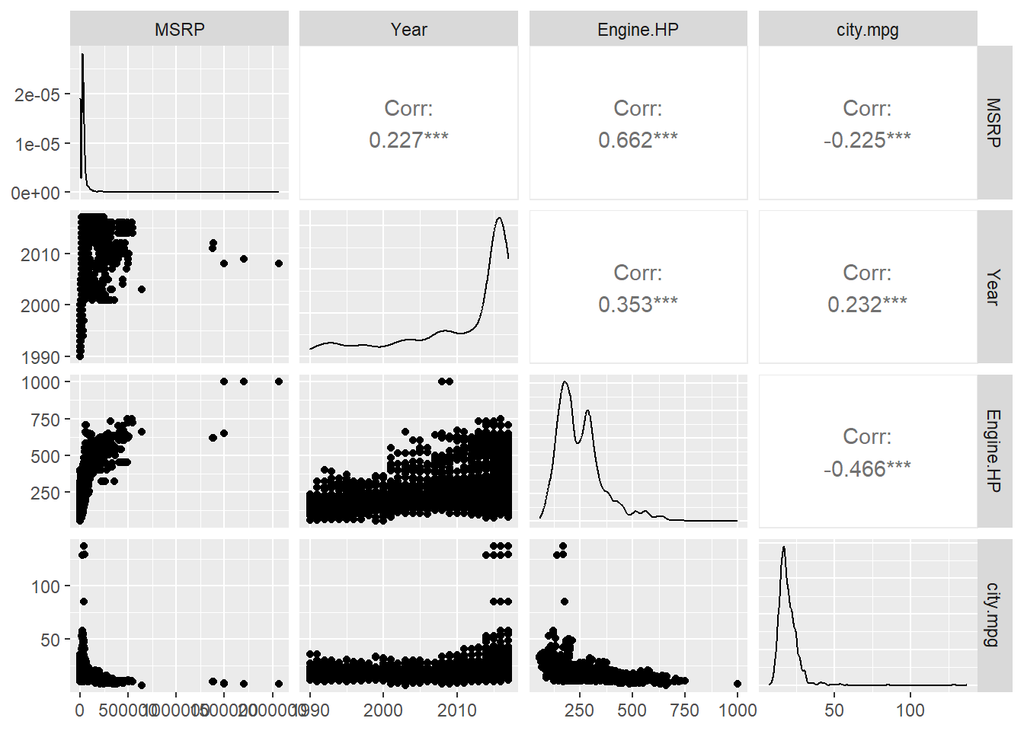

```r
ggpairs(auto_omit_continous)
```

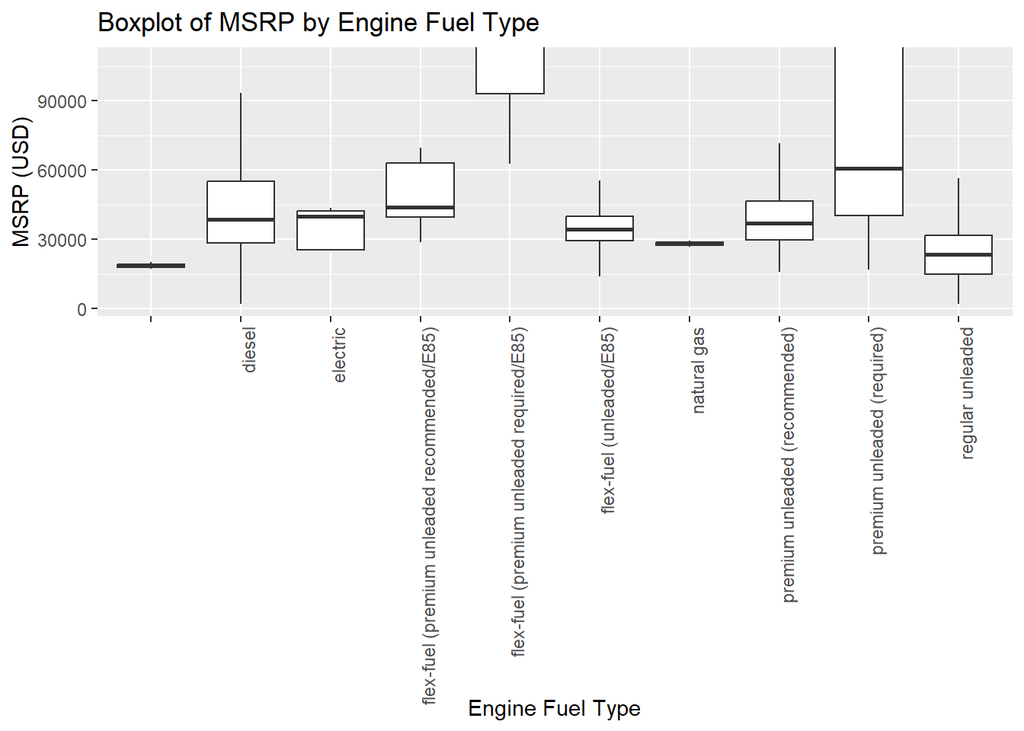

```r
#BoxPlots
#ggplot(auto_omit, aes(x= Make, y= MSRP)) +
#  geom_boxplot(outlier.shape = NA) +
#  coord_cartesian(ylim = quantile(auto_omit$MSRP, c(0.05, 0.95))) +
#  labs(title = "Boxplot of MSRP by Car Make", x = "Make", y = "MSRP (USD)") +
#  theme(axis.text.x = element_text(angle = 90, hjust = 1))

ggplot(auto_omit, aes(x= Engine.Fuel.Type, y= MSRP)) +  ### Empty??
  geom_boxplot(outlier.shape = NA) +
  coord_cartesian(ylim = quantile(auto_omit$MSRP, c(0.05, 0.95))) +
  labs(title = "Boxplot of MSRP by Engine Fuel Type", x = "Engine Fuel Type", y = "MSRP (USD)") +
  theme(axis.text.x = element_text(angle = 90, hjust = 1))
```

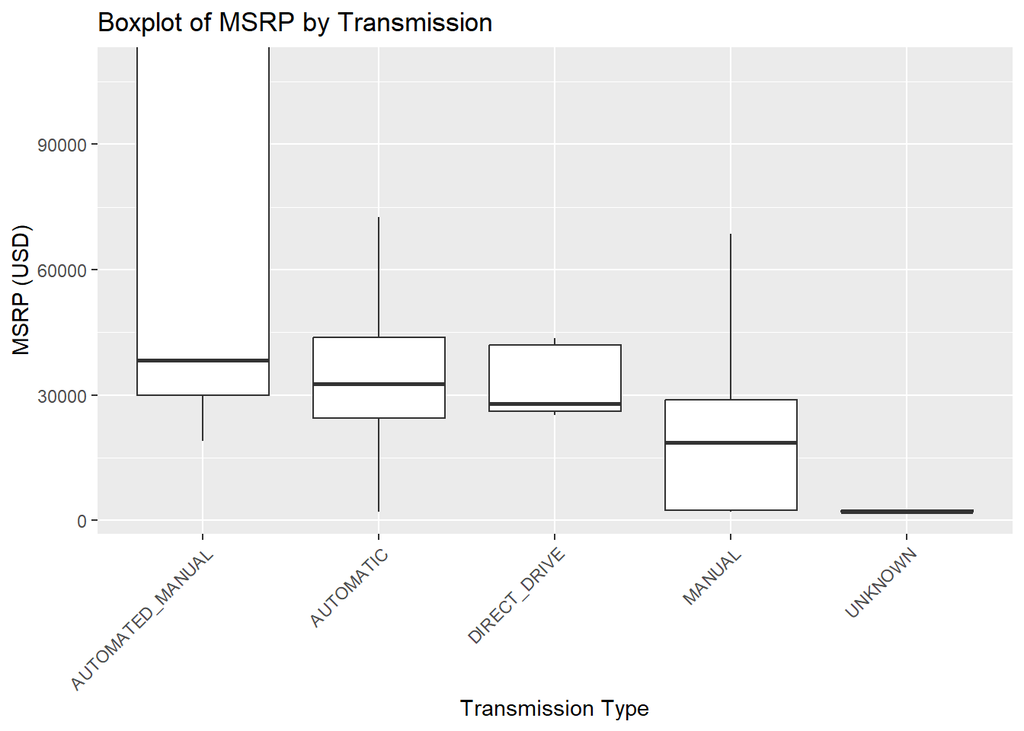

```r
ggplot(auto_omit, aes(x= Transmission.Type, y= MSRP)) + #Unknown LOL
  geom_boxplot(outlier.shape = NA) +
  coord_cartesian(ylim = quantile(auto_omit$MSRP, c(0.05, 0.95))) +
  labs(title = "Boxplot of MSRP by Transmission", x = "Transmission Type", y = "MSRP (USD)") +
  theme(axis.text.x = element_text(angle = 45, hjust = 1))
```

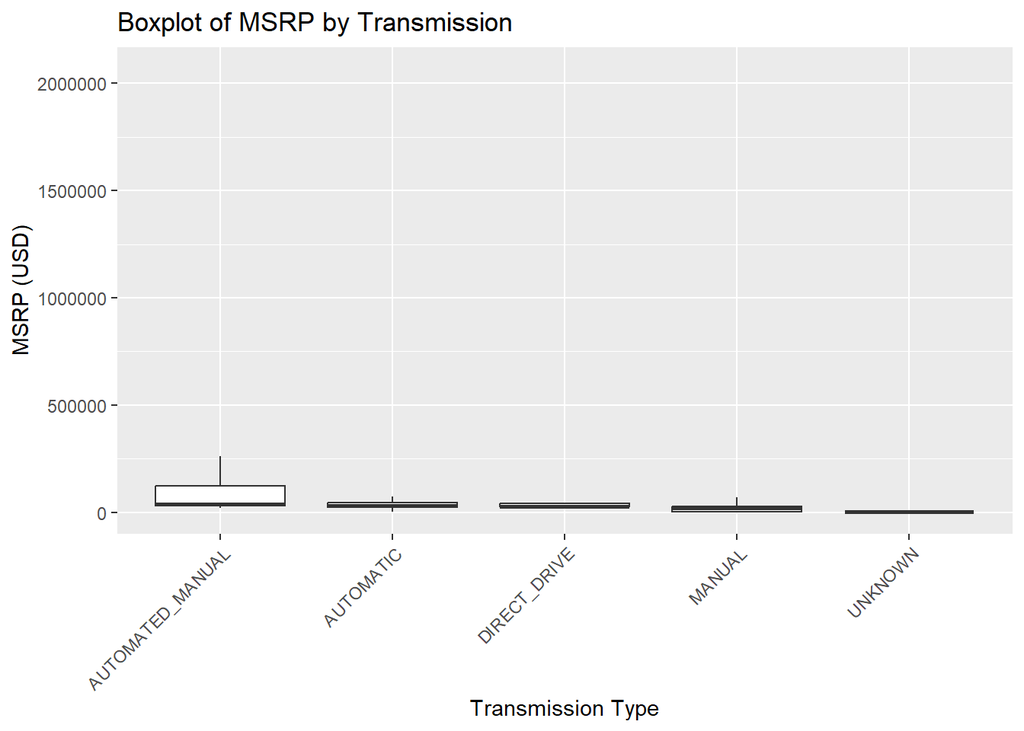

```r
ggplot(auto_omit, aes(x= Transmission.Type, y= MSRP)) + #Unknown LOL
  geom_boxplot(outlier.shape = NA) +
  labs(title = "Boxplot of MSRP by Transmission", x = "Transmission Type", y = "MSRP (USD)") +
  theme(axis.text.x = element_text(angle = 45, hjust = 1))
```

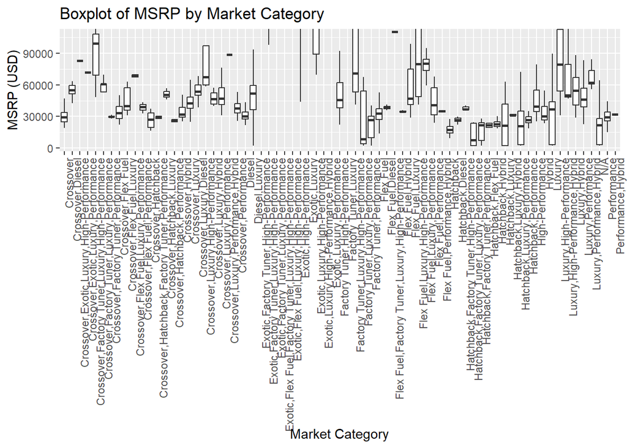

```r
ggplot(auto_omit, aes(x= Market.Category, y= MSRP)) +
  geom_boxplot(outlier.shape = NA) +
  coord_cartesian(ylim = quantile(auto_omit$MSRP, c(0.05, 0.95))) +
  labs(title = "Boxplot of MSRP by Market Category", x = "Market Category", y = "MSRP (USD)") +
  theme(axis.text.x = element_text(angle = 90, hjust = 1))
```

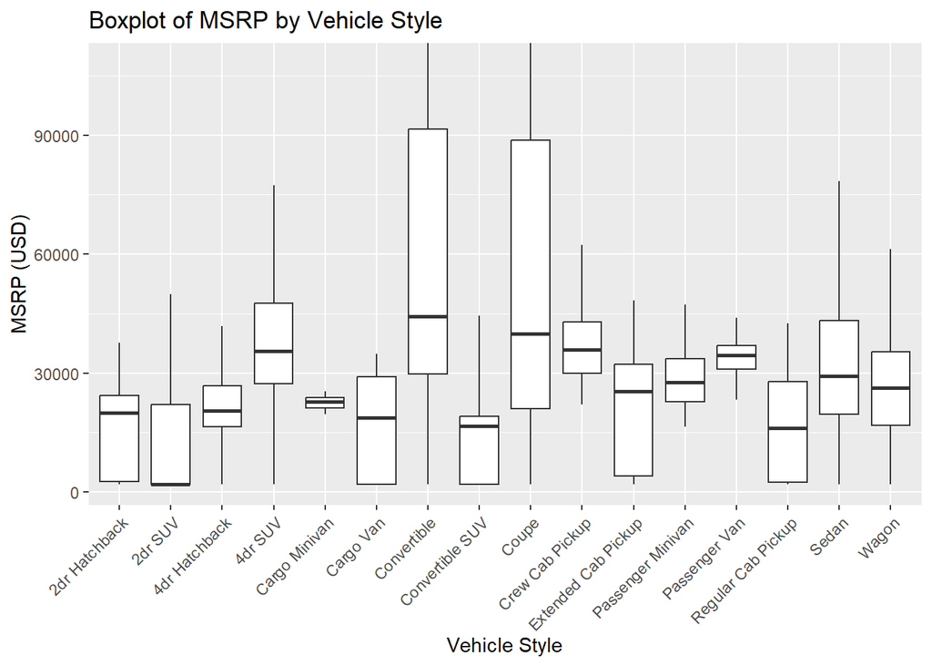

```r
#ggplot(auto_omit, aes(x= Vehicle.Size, y= MSRP)) +
#  geom_boxplot(outlier.shape = NA) +
#  coord_cartesian(ylim = quantile(auto_omit$MSRP, c(0.05, 0.95))) +
#  labs(title = "Boxplot of MSRP by Vehicle Size", x = "Vehicle Size", y = "MSRP (USD)") +
#  theme(axis.text.x = element_text(angle = 45, hjust = 1))

ggplot(auto_omit, aes(x= Vehicle.Style, y= MSRP)) +
  geom_boxplot(outlier.shape = NA) +
  coord_cartesian(ylim = quantile(auto_omit$MSRP, c(0.05, 0.95))) +
  labs(title = "Boxplot of MSRP by Vehicle Style", x = "Vehicle Style", y = "MSRP (USD)") +
  theme(axis.text.x = element_text(angle = 45, hjust = 1))
```

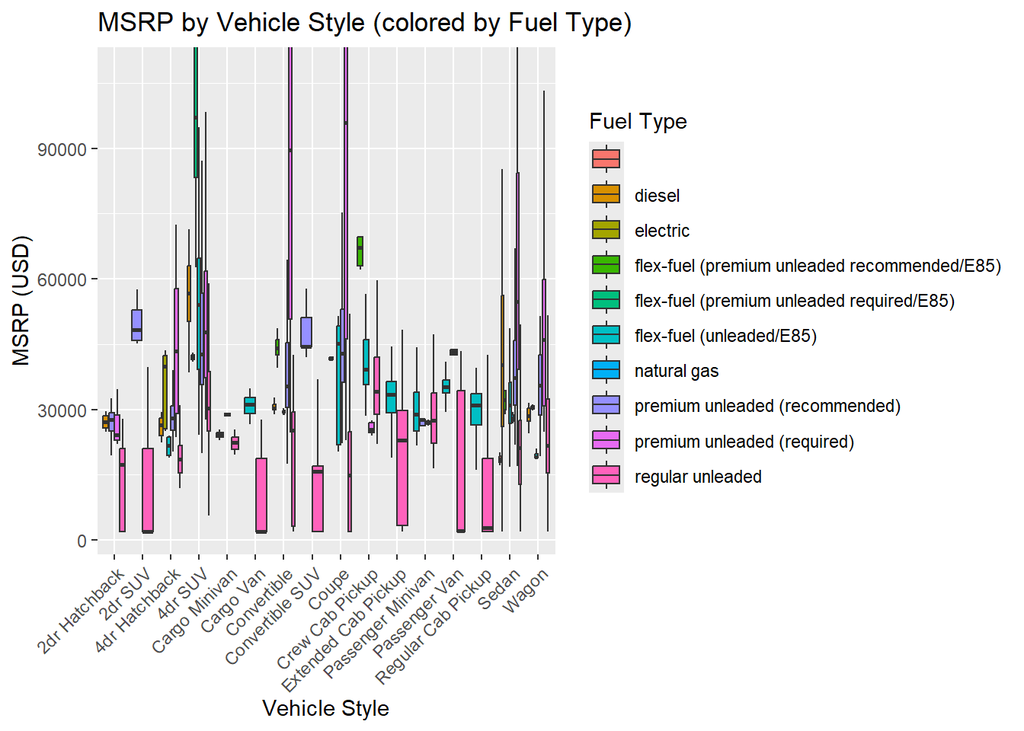

```r
#Wayyyy too cluttered
ggplot(auto_omit, aes(x = Vehicle.Style, y = MSRP, fill = Engine.Fuel.Type)) +
  geom_boxplot(outlier.shape = NA, position = position_dodge(width = 0.8)) +
  coord_cartesian(ylim = quantile(auto_omit$MSRP, c(0.05, 0.95))) +
  labs(title = "MSRP by Vehicle Style (colored by Fuel Type)", x = "Vehicle Style", y = "MSRP (USD)", fill = "Fuel Type") +
  theme(axis.text.x = element_text(angle = 45, hjust = 1))
```

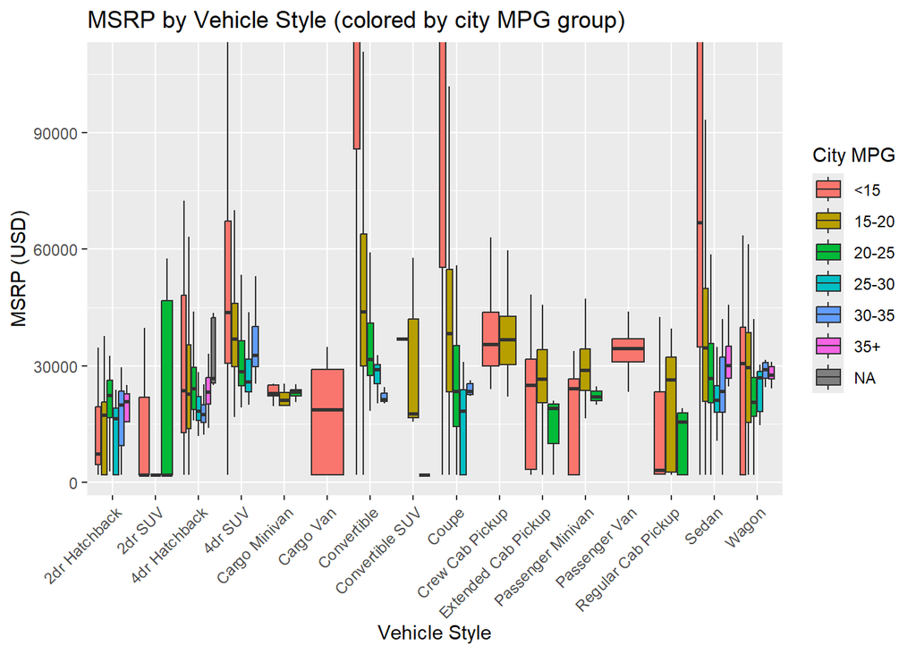

```r
ggplot(auto_omit, aes(x = Vehicle.Style, y = MSRP, fill = MPG_bin)) +
  geom_boxplot(outlier.shape = NA, position = position_dodge(width = 0.8)) +
  coord_cartesian(ylim = quantile(auto_omit$MSRP, c(0.05, 0.95))) +
  labs(title = "MSRP by Vehicle Style (colored by city MPG group)", x = "Vehicle Style", y = "MSRP (USD)", fill = "City MPG") +
  theme(axis.text.x = element_text(angle = 45, hjust = 1))
```

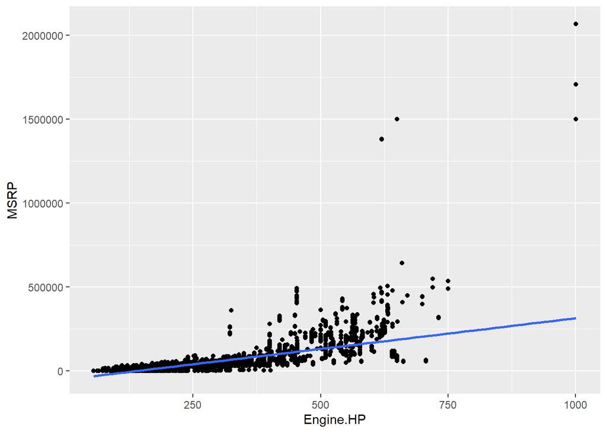

```r
#ggplot(auto_omit, aes(x= Engine.Cylinders, y= MSRP)) +
#  geom_boxplot(outlier.shape = NA) +
#  coord_cartesian(ylim = quantile(auto_omit$MSRP, c(0.05, 0.95))) +
#  labs(title = "Boxplot of MSRP by Engine Cylinder", x = "Engine Cylinder", y = "MSRP (USD)") +
#  theme(axis.text.x = element_text(angle = 45, hjust = 1))

#ggplot(auto_omit, aes(x= Year, y= MSRP)) +
#  geom_boxplot(outlier.shape = NA) +
#  coord_cartesian(ylim = quantile(auto_omit$MSRP, c(0.05, 0.95))) +
#  labs(title = "Boxplot of MSRP by Year", x = "Year", y = "MSRP (USD)") +
#  theme(axis.text.x = element_text(angle = 45, hjust = 1))

#ggplot(auto_omit, aes(x= Driven_Wheels, y= MSRP)) +
#  geom_boxplot(outlier.shape = NA) +
#  coord_cartesian(ylim = quantile(auto_omit$MSRP, c(0.05, 0.95))) +
#  labs(title = "Boxplot of MSRP by Drive Type", x = "Drive Type", y = "MSRP (USD)") +
#  theme(axis.text.x = element_text(angle = 45, hjust = 1))

#ScatterPlots
ggplot(auto_omit, aes(x = `Engine.HP`, y = MSRP)) +
  geom_point() +
  geom_smooth(method='lm')
```

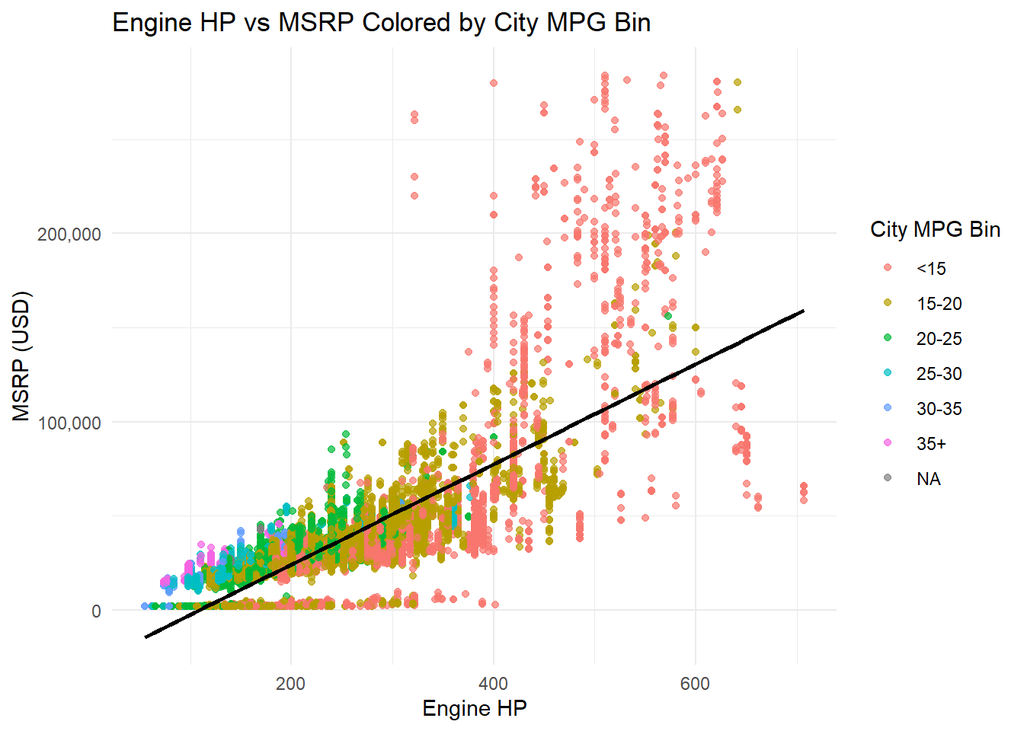

```r
ggplot(auto_omit_reduced_no_outliers, aes(x = `Engine.HP`, y = MSRP, color = MPG_bin)) +
  geom_point(alpha = 0.7) +
  geom_smooth(method = 'lm', se = FALSE, color = "black") +
  labs(
    title = "Engine HP vs MSRP Colored by City MPG Bin",
    x = "Engine HP",
    y = "MSRP (USD)",
    color = "City MPG Bin"
  ) +
  scale_y_continuous(labels = scales::comma)+
  theme_minimal()
```

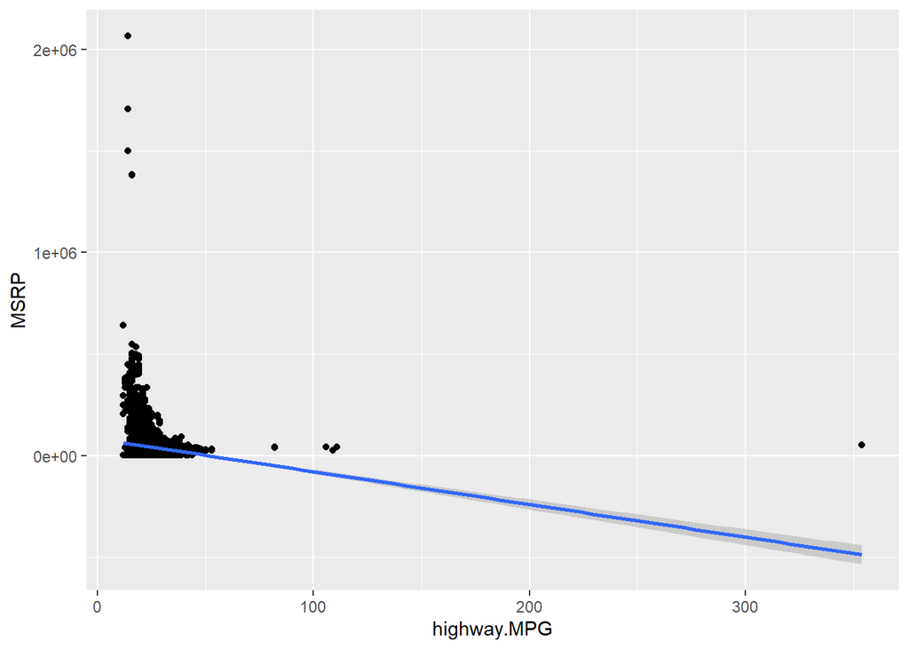

```r
ggplot(auto_omit, aes(x = `highway.MPG`, y = MSRP)) +
  geom_point() +
  geom_smooth(method='lm')
```

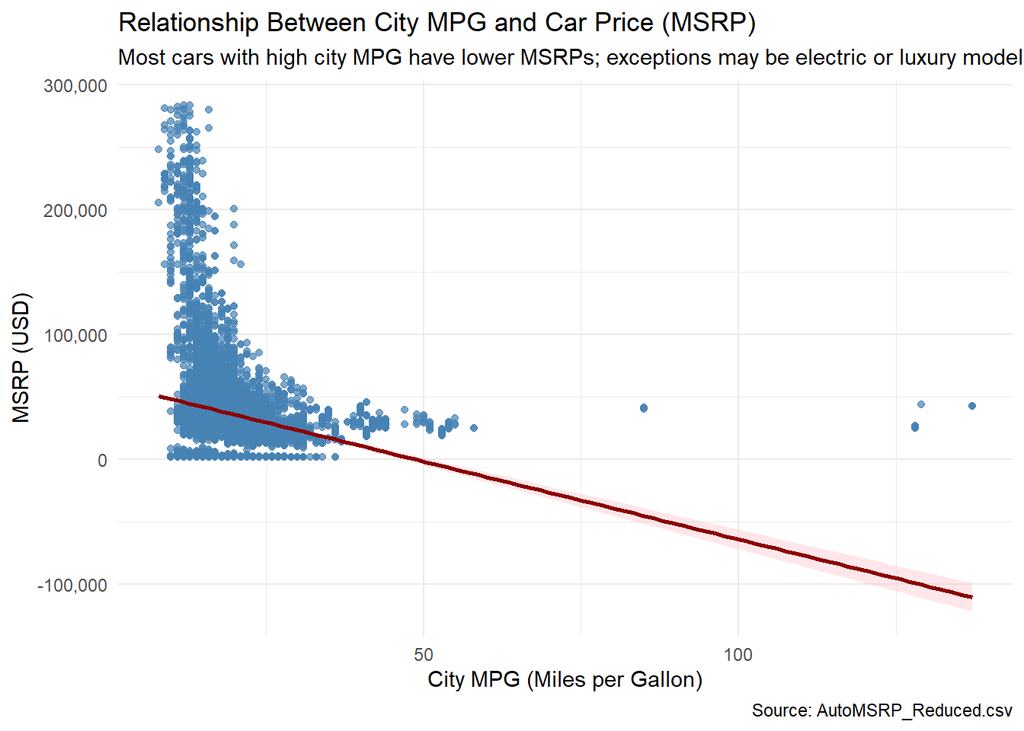

```r
ggplot(auto_omit_reduced_no_outliers, aes(x = city.mpg, y = MSRP)) +
  geom_point(alpha = 0.7, color = "steelblue") +
  geom_smooth(method = 'lm', se = TRUE, color = "darkred", fill = "pink") +
  labs(
    title = "Relationship Between City MPG and Car Price (MSRP)",
    subtitle = "Most cars with high city MPG have lower MSRPs; exceptions may be electric or luxury models",
    x = "City MPG (Miles per Gallon)",
    y = "MSRP (USD)",
    caption = "Source: AutoMSRP_Reduced.csv"
  ) +
  scale_y_continuous(labels = comma) +
  theme_minimal()
```

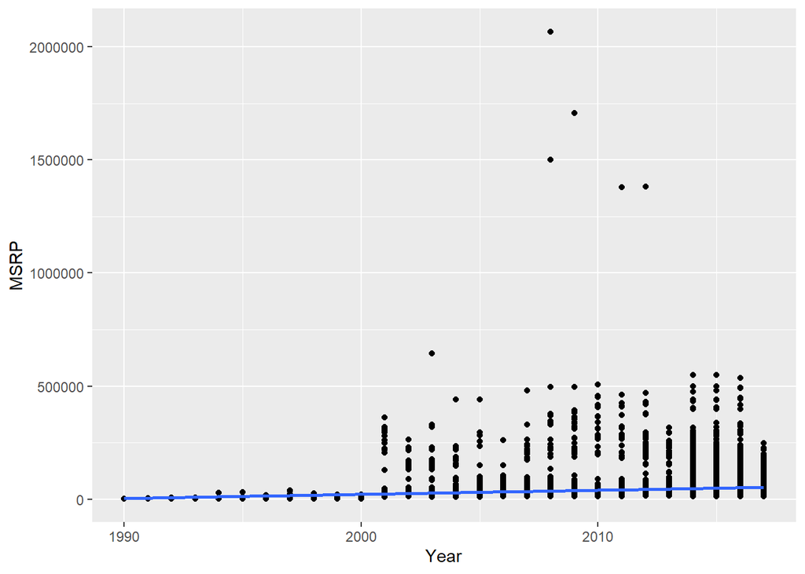

```r
ggplot(auto_omit, aes(x = `Year`, y = MSRP)) +
  geom_point() +
  geom_smooth(method='lm')
```

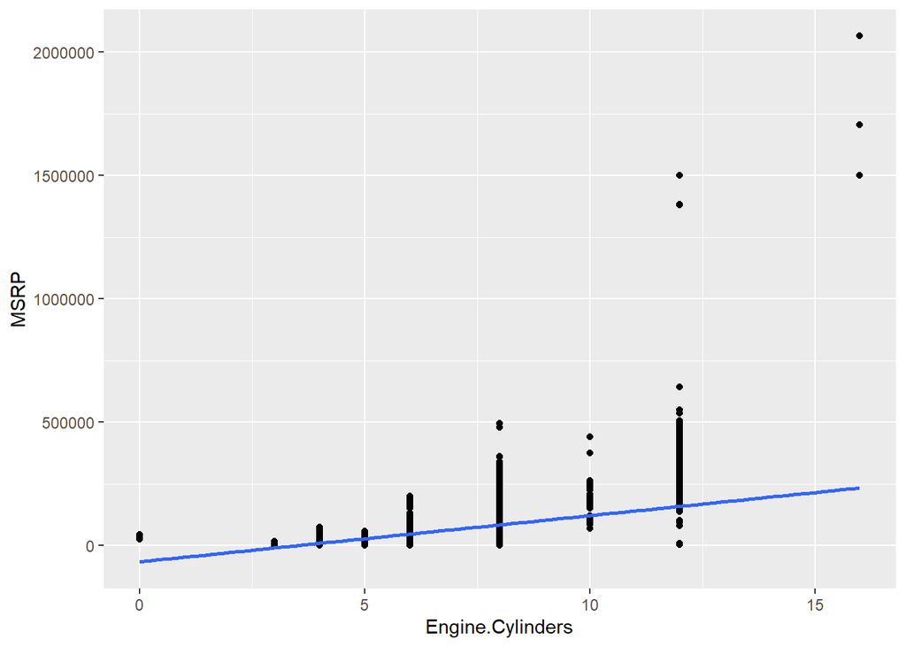

```r
ggplot(auto_omit, aes(x = `Engine.Cylinders`, y = MSRP)) +
  geom_point() +
  geom_smooth(method='lm')
```

```r
#Corr Matrix
cor_matrix <- cor(auto_omit_continous, use = "complete.obs")
print(cor_matrix)
```

```
##                 MSRP      Year  Engine.HP   city.mpg
## MSRP       1.0000000 0.2273806  0.6618332 -0.2252765
## Year       0.2273806 1.0000000  0.3529804  0.2324394
## Engine.HP  0.6618332 0.3529804  1.0000000 -0.4659030
## city.mpg  -0.2252765 0.2324394 -0.4659030  1.0000000
```

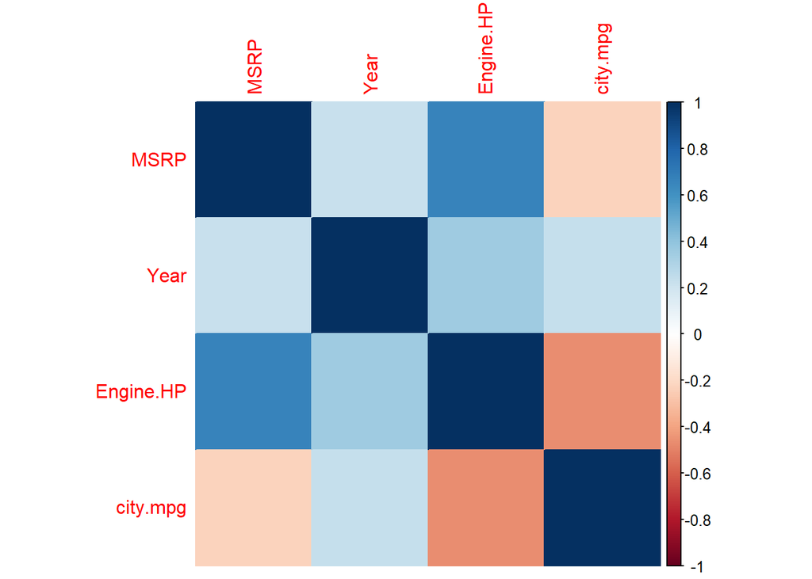

```r
corrplot(cor_matrix, method = "color")
```

```r
#Categorical Var. Fun Stats
category_summary <- function(df, var) {
  tab <- table(df[[var]])
  data.frame(
    Variable      = var,
    N_Categories  = length(tab),
    Most_Common   = names(tab)[which.max(tab)],
    N_Most_Common = max(tab),
    Least_Common  = names(tab)[which.min(tab)],
    N_Least_Common = min(tab),
    stringsAsFactors = FALSE
  )
}
cat_summary <- do.call(rbind, lapply(cat_cols, function(x) category_summary(auto_omit_reduced_no_outliers, x)))

print(cat_summary)
```

```
##            Variable N_Categories       Most_Common N_Most_Common
## 1  Engine.Fuel.Type           10  regular unleaded          7155
## 2 Transmission.Type            5         AUTOMATIC          8164
## 3     Driven_Wheels            4 front wheel drive          4735
## 4   Market.Category           71               N/A          3731
## 5     Vehicle.Style           16             Sedan          2985
##                              Least_Common N_Least_Common
## 1                             natural gas              2
## 2                            DIRECT_DRIVE             15
## 3                        four wheel drive           1403
## 4 Exotic,Factory Tuner,Luxury,Performance              0
## 5                         Convertible SUV             29
```

```r
#Removing MPG_bin for modeling purposes
auto_omit <- dplyr::select(auto_omit, -MPG_bin)
auto_omit_reduced_no_outliers <- dplyr::select(auto_omit_reduced_no_outliers, -MPG_bin)
```

#Feature Selection and Ojective 1 Model ##Using Domain Knowledge to remove Attributes - City and Highway MPG have high correlation and measure very similar things - Engine HP and Cylinder are closely related - Vehicle Style and Size are also - No. of Doors could also be connected to Style - Market Category and Make tend to be closely related as well.

Removing Highway.MPG, Engine.Cylinder, Vehicle.Size, No. of Doors, Make (The new DF will be created up above)

```r
# Full Model (all predictors)
full.model <- lm(MSRP ~ ., data = auto_omit_reduced)
full.model_noout <- lm(MSRP ~ ., data = auto_omit_reduced_no_outliers)

# Null Model (only intercept)
null.model <- lm(MSRP ~ 1, data = auto_omit_reduced)
null.model_noout <- lm(MSRP ~ 1, data = auto_omit_reduced_no_outliers)

# Forward Selection
#MSRP ~ Market.Category + Engine.HP + Driven_Wheels + Transmission.Type + Vehicle.Style + city.mpg + Engine.Fuel.Type + Year #AIC 247273.4 (Noout)
forward <- step(null.model, scope = formula(full.model), direction = "forward")
```

```
## Start:  AIC=260089.6
## MSRP ~ 1
##
##                     Df  Sum of Sq        RSS    AIC
## + Market.Category   70 2.3829e+13 1.9096e+13 250660
## + Engine.HP          1 1.8802e+13 2.4123e+13 253283
## + Engine.Fuel.Type   9 1.0540e+13 3.2385e+13 256779
## + Vehicle.Style     15 4.5294e+12 3.8395e+13 258802
## + Driven_Wheels      3 2.9790e+12 3.9946e+13 259246
## + Transmission.Type  4 2.7426e+12 4.0182e+13 259318
## + Year               1 2.2193e+12 4.0705e+13 259464
## + city.mpg           1 2.1784e+12 4.0746e+13 259476
## <none>                            4.2925e+13 260090
##
## Step:  AIC=250659.6
## MSRP ~ Market.Category
##
##                     Df  Sum of Sq        RSS    AIC
## + Engine.HP          1 3.7860e+12 1.5310e+13 248051
## + Year               1 8.8736e+11 1.8208e+13 250099
## + Transmission.Type  4 7.4195e+11 1.8354e+13 250199
## + Driven_Wheels      3 3.9972e+11 1.8696e+13 250416
## + Vehicle.Style     14 4.1174e+11 1.8684e+13 250430
## + Engine.Fuel.Type   9 3.2269e+11 1.8773e+13 250476
## + city.mpg           1 7.4923e+10 1.9021e+13 250615
## <none>                            1.9096e+13 250660
##
## Step:  AIC=248050.8
## MSRP ~ Market.Category + Engine.HP
##
##                     Df  Sum of Sq        RSS    AIC
## + Driven_Wheels      3 4.7877e+11 1.4831e+13 247681
## + Vehicle.Style     14 3.7735e+11 1.4932e+13 247784
## + Transmission.Type  4 3.0195e+11 1.5008e+13 247823
## + city.mpg           1 2.6671e+11 1.5043e+13 247845
## + Engine.Fuel.Type   9 1.3905e+11 1.5171e+13 247961
## + Year               1 1.0195e+11 1.5208e+13 247974
## <none>                            1.5310e+13 248051
##
## Step:  AIC=247681.4
```

[output cut: 35 more lines]

```
## + Engine.Fuel.Type  9 7.1115e+10 1.4260e+13 247273
## + Year              1 1.2185e+10 1.4319e+13 247306
## <none>                           1.4331e+13 247314
##
## Step:  AIC=247273.4
## MSRP ~ Market.Category + Engine.HP + Driven_Wheels + Transmission.Type +
##     Vehicle.Style + city.mpg + Engine.Fuel.Type
##
##        Df  Sum of Sq        RSS    AIC
## + Year  1 2.1299e+10 1.4238e+13 247258
## <none>               1.4260e+13 247273
##
## Step:  AIC=247257.7
## MSRP ~ Market.Category + Engine.HP + Driven_Wheels + Transmission.Type +
##     Vehicle.Style + city.mpg + Engine.Fuel.Type + Year
```

```r
forward_noout <- step(null.model, scope = formula(full.model_noout), direction = "forward")
```

```
## Start:  AIC=260089.6
## MSRP ~ 1
##
##                     Df  Sum of Sq        RSS    AIC
## + Market.Category   70 2.3829e+13 1.9096e+13 250660
## + Engine.HP          1 1.8802e+13 2.4123e+13 253283
## + Engine.Fuel.Type   9 1.0540e+13 3.2385e+13 256779
## + Vehicle.Style     15 4.5294e+12 3.8395e+13 258802
## + Driven_Wheels      3 2.9790e+12 3.9946e+13 259246
## + Transmission.Type  4 2.7426e+12 4.0182e+13 259318
## + Year               1 2.2193e+12 4.0705e+13 259464
## + city.mpg           1 2.1784e+12 4.0746e+13 259476
## <none>                            4.2925e+13 260090
##
## Step:  AIC=250659.6
## MSRP ~ Market.Category
##
##                     Df  Sum of Sq        RSS    AIC
## + Engine.HP          1 3.7860e+12 1.5310e+13 248051
## + Year               1 8.8736e+11 1.8208e+13 250099
## + Transmission.Type  4 7.4195e+11 1.8354e+13 250199
## + Driven_Wheels      3 3.9972e+11 1.8696e+13 250416
## + Vehicle.Style     14 4.1174e+11 1.8684e+13 250430
## + Engine.Fuel.Type   9 3.2269e+11 1.8773e+13 250476
## + city.mpg           1 7.4923e+10 1.9021e+13 250615
## <none>                            1.9096e+13 250660
##
## Step:  AIC=248050.8
## MSRP ~ Market.Category + Engine.HP
##
##                     Df  Sum of Sq        RSS    AIC
## + Driven_Wheels      3 4.7877e+11 1.4831e+13 247681
## + Vehicle.Style     14 3.7735e+11 1.4932e+13 247784
## + Transmission.Type  4 3.0195e+11 1.5008e+13 247823
## + city.mpg           1 2.6671e+11 1.5043e+13 247845
## + Engine.Fuel.Type   9 1.3905e+11 1.5171e+13 247961
## + Year               1 1.0195e+11 1.5208e+13 247974
## <none>                            1.5310e+13 248051
##
## Step:  AIC=247681.4
```

[output cut: 35 more lines]

```
## + Engine.Fuel.Type  9 7.1115e+10 1.4260e+13 247273
## + Year              1 1.2185e+10 1.4319e+13 247306
## <none>                           1.4331e+13 247314
##
## Step:  AIC=247273.4
## MSRP ~ Market.Category + Engine.HP + Driven_Wheels + Transmission.Type +
##     Vehicle.Style + city.mpg + Engine.Fuel.Type
##
##        Df  Sum of Sq        RSS    AIC
## + Year  1 2.1299e+10 1.4238e+13 247258
## <none>               1.4260e+13 247273
##
## Step:  AIC=247257.7
## MSRP ~ Market.Category + Engine.HP + Driven_Wheels + Transmission.Type +
##     Vehicle.Style + city.mpg + Engine.Fuel.Type + Year
```

```r
# Backward Elimination
#MSRP ~ Market.Category + Engine.HP + Driven_Wheels + Transmission.Type + Vehicle.Style + city.mpg + Engine.Fuel.Type + Year
backward <- step(full.model, direction = "backward")
```

```
## Start:  AIC=247257.7
## MSRP ~ Year + Engine.Fuel.Type + Engine.HP + Transmission.Type +
##     Driven_Wheels + Market.Category + Vehicle.Style + city.mpg
##
##                     Df  Sum of Sq        RSS    AIC
## <none>                            1.4238e+13 247258
## - Year               1 2.1299e+10 1.4260e+13 247273
## - Engine.Fuel.Type   9 8.0228e+10 1.4319e+13 247306
## - Transmission.Type  4 1.2386e+11 1.4362e+13 247352
## - Vehicle.Style     14 1.7015e+11 1.4409e+13 247370
## - city.mpg           1 1.3999e+11 1.4378e+13 247371
## - Driven_Wheels      3 1.9764e+11 1.4436e+13 247415
## - Engine.HP          1 2.4946e+12 1.6733e+13 249163
## - Market.Category   69 7.3004e+12 2.1539e+13 252010
```

```r
backward_noout <- step(full.model_noout, direction = "backward")
```

```
## Start:  AIC=221488.9
## MSRP ~ Year + Engine.Fuel.Type + Engine.HP + Transmission.Type +
##     Driven_Wheels + Market.Category + Vehicle.Style + city.mpg
##
##                     Df  Sum of Sq        RSS    AIC
## <none>                            1.9261e+12 221489
## - city.mpg           1 3.5303e+09 1.9297e+12 221508
## - Transmission.Type  4 2.6759e+10 1.9529e+12 221642
## - Driven_Wheels      3 5.5263e+10 1.9814e+12 221814
## - Year               1 7.0175e+10 1.9963e+12 221905
## - Engine.Fuel.Type   9 8.1647e+10 2.0078e+12 221956
## - Vehicle.Style     14 9.0603e+10 2.0167e+12 221999
## - Engine.HP          1 5.6332e+11 2.4895e+12 224487
## - Market.Category   68 2.5075e+12 4.4336e+12 231104
```

```r
# Stepwise Selection
#MSRP ~ Market.Category + Engine.HP + Driven_Wheels + Transmission.Type + Vehicle.Style + city.mpg + Engine.Fuel.Type + Year
stepwise <- step(null.model, scope = formula(full.model), direction = "both")
```

```
## Start:  AIC=260089.6
## MSRP ~ 1
##
##                     Df  Sum of Sq        RSS    AIC
## + Market.Category   70 2.3829e+13 1.9096e+13 250660
## + Engine.HP          1 1.8802e+13 2.4123e+13 253283
## + Engine.Fuel.Type   9 1.0540e+13 3.2385e+13 256779
## + Vehicle.Style     15 4.5294e+12 3.8395e+13 258802
## + Driven_Wheels      3 2.9790e+12 3.9946e+13 259246
## + Transmission.Type  4 2.7426e+12 4.0182e+13 259318
## + Year               1 2.2193e+12 4.0705e+13 259464
## + city.mpg           1 2.1784e+12 4.0746e+13 259476
## <none>                            4.2925e+13 260090
##
## Step:  AIC=250659.6
## MSRP ~ Market.Category
##
##                     Df  Sum of Sq        RSS    AIC
## + Engine.HP          1 3.7860e+12 1.5310e+13 248051
## + Year               1 8.8736e+11 1.8208e+13 250099
## + Transmission.Type  4 7.4195e+11 1.8354e+13 250199
## + Driven_Wheels      3 3.9972e+11 1.8696e+13 250416
## + Vehicle.Style     14 4.1174e+11 1.8684e+13 250430
## + Engine.Fuel.Type   9 3.2269e+11 1.8773e+13 250476
## + city.mpg           1 7.4923e+10 1.9021e+13 250615
## <none>                            1.9096e+13 250660
## - Market.Category   70 2.3829e+13 4.2925e+13 260090
##
## Step:  AIC=248050.8
## MSRP ~ Market.Category + Engine.HP
##
##                     Df  Sum of Sq        RSS    AIC
## + Driven_Wheels      3 4.7877e+11 1.4831e+13 247681
## + Vehicle.Style     14 3.7735e+11 1.4932e+13 247784
## + Transmission.Type  4 3.0195e+11 1.5008e+13 247823
## + city.mpg           1 2.6671e+11 1.5043e+13 247845
## + Engine.Fuel.Type   9 1.3905e+11 1.5171e+13 247961
## + Year               1 1.0195e+11 1.5208e+13 247974
## <none>                            1.5310e+13 248051
## - Engine.HP          1 3.7860e+12 1.9096e+13 250660
```

[output cut: 74 more lines]

```
##
## Step:  AIC=247257.7
## MSRP ~ Market.Category + Engine.HP + Driven_Wheels + Transmission.Type +
##     Vehicle.Style + city.mpg + Engine.Fuel.Type + Year
##
##                     Df  Sum of Sq        RSS    AIC
## <none>                            1.4238e+13 247258
## - Year               1 2.1299e+10 1.4260e+13 247273
## - Engine.Fuel.Type   9 8.0228e+10 1.4319e+13 247306
## - Transmission.Type  4 1.2386e+11 1.4362e+13 247352
## - Vehicle.Style     14 1.7015e+11 1.4409e+13 247370
## - city.mpg           1 1.3999e+11 1.4378e+13 247371
## - Driven_Wheels      3 1.9764e+11 1.4436e+13 247415
## - Engine.HP          1 2.4946e+12 1.6733e+13 249163
## - Market.Category   69 7.3004e+12 2.1539e+13 252010
```

```r
stepwise_noout <- step(null.model, scope = formula(full.model_noout), direction = "both")
```

```
## Start:  AIC=260089.6
## MSRP ~ 1
##
##                     Df  Sum of Sq        RSS    AIC
## + Market.Category   70 2.3829e+13 1.9096e+13 250660
## + Engine.HP          1 1.8802e+13 2.4123e+13 253283
## + Engine.Fuel.Type   9 1.0540e+13 3.2385e+13 256779
## + Vehicle.Style     15 4.5294e+12 3.8395e+13 258802
## + Driven_Wheels      3 2.9790e+12 3.9946e+13 259246
## + Transmission.Type  4 2.7426e+12 4.0182e+13 259318
## + Year               1 2.2193e+12 4.0705e+13 259464
## + city.mpg           1 2.1784e+12 4.0746e+13 259476
## <none>                            4.2925e+13 260090
##
## Step:  AIC=250659.6
## MSRP ~ Market.Category
##
##                     Df  Sum of Sq        RSS    AIC
## + Engine.HP          1 3.7860e+12 1.5310e+13 248051
## + Year               1 8.8736e+11 1.8208e+13 250099
## + Transmission.Type  4 7.4195e+11 1.8354e+13 250199
## + Driven_Wheels      3 3.9972e+11 1.8696e+13 250416
## + Vehicle.Style     14 4.1174e+11 1.8684e+13 250430
## + Engine.Fuel.Type   9 3.2269e+11 1.8773e+13 250476
## + city.mpg           1 7.4923e+10 1.9021e+13 250615
## <none>                            1.9096e+13 250660
## - Market.Category   70 2.3829e+13 4.2925e+13 260090
##
## Step:  AIC=248050.8
## MSRP ~ Market.Category + Engine.HP
##
##                     Df  Sum of Sq        RSS    AIC
## + Driven_Wheels      3 4.7877e+11 1.4831e+13 247681
## + Vehicle.Style     14 3.7735e+11 1.4932e+13 247784
## + Transmission.Type  4 3.0195e+11 1.5008e+13 247823
## + city.mpg           1 2.6671e+11 1.5043e+13 247845
## + Engine.Fuel.Type   9 1.3905e+11 1.5171e+13 247961
## + Year               1 1.0195e+11 1.5208e+13 247974
## <none>                            1.5310e+13 248051
## - Engine.HP          1 3.7860e+12 1.9096e+13 250660
```

[output cut: 74 more lines]

```
##
## Step:  AIC=247257.7
## MSRP ~ Market.Category + Engine.HP + Driven_Wheels + Transmission.Type +
##     Vehicle.Style + city.mpg + Engine.Fuel.Type + Year
##
##                     Df  Sum of Sq        RSS    AIC
## <none>                            1.4238e+13 247258
## - Year               1 2.1299e+10 1.4260e+13 247273
## - Engine.Fuel.Type   9 8.0228e+10 1.4319e+13 247306
## - Transmission.Type  4 1.2386e+11 1.4362e+13 247352
## - Vehicle.Style     14 1.7015e+11 1.4409e+13 247370
## - city.mpg           1 1.3999e+11 1.4378e+13 247371
## - Driven_Wheels      3 1.9764e+11 1.4436e+13 247415
## - Engine.HP          1 2.4946e+12 1.6733e+13 249163
## - Market.Category   69 7.3004e+12 2.1539e+13 252010
```

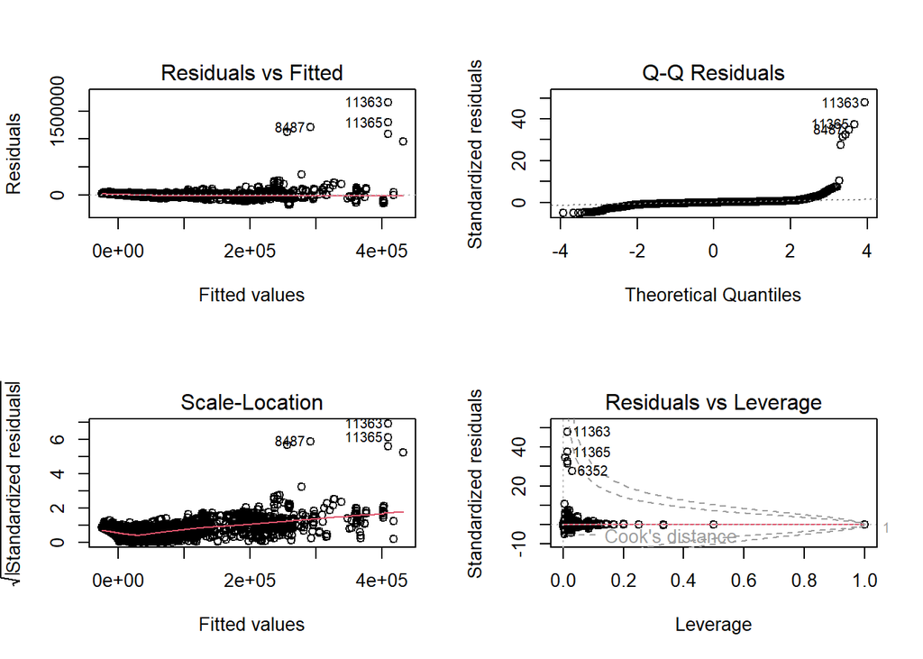

```r
#Each of the above feature selection had the exact same Model

#Full Model and full model_noout Assumption
par(mfrow = c(2, 2))
plot(full.model)
```

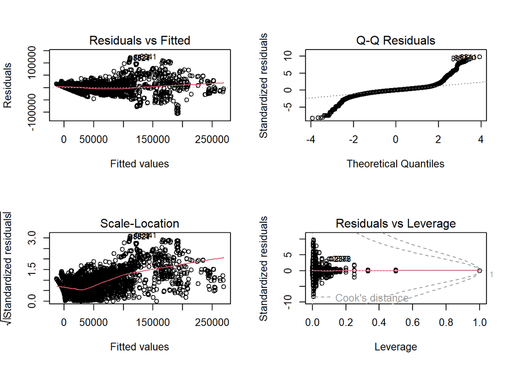

```r
plot(full.model_noout)
```

```r
par(mfrow = c(1, 1))

#penafull.model#penalized selection
fitControl<-trainControl(method="repeatedcv",number=10,repeats=1)

glmnet.fit<-train(MSRP~.,
               data=auto_omit_reduced,
               method="glmnet",
               trControl=fitControl
               )
opt.pen<-glmnet.fit$finalModel$lambdaOpt
#coef(glmnet.fit$finalModel,opt.pen)
glmnet.fit
```

```
## glmnet
##
## 11815 samples
##     8 predictor
##
## No pre-processing
## Resampling: Cross-Validated (10 fold, repeated 1 times)
## Summary of sample sizes: 10632, 10634, 10632, 10634, 10634, 10634, ...
## Resampling results across tuning parameters:
##
##   alpha  lambda      RMSE      Rsquared   MAE
##   0.10     79.78392  32410.01  0.7230170  12707.49
##   0.10    797.83917  32322.28  0.7231997  12201.32
##   0.10   7978.39175  33120.47  0.7095145  11304.22
##   0.55     79.78392  32391.21  0.7231310  12621.13
##   0.55    797.83917  32513.43  0.7190608  12115.22
##   0.55   7978.39175  36745.63  0.6521967  14126.62
##   1.00     79.78392  32379.59  0.7231159  12536.20
##   1.00    797.83917  32840.86  0.7131326  12288.34
##   1.00   7978.39175  39523.41  0.6022948  15026.99
##
## RMSE was used to select the optimal model using the smallest value.
## The final values used for the model were alpha = 0.1 and lambda = 797.8392.
```

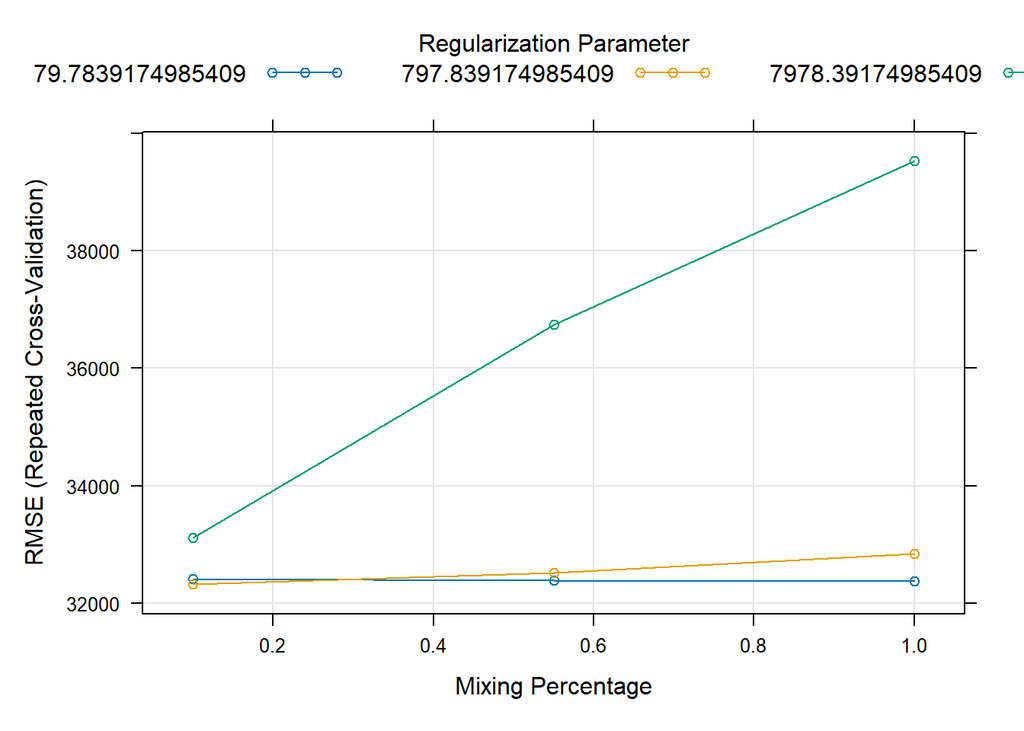

```r
#coefs <- coef(glmnet.fit$finalModel, glmnet.fit$finalModel$lambdaOpt)
#active_predictors <- rownames(coefs)[as.numeric(coefs) != 0]
#active_predictors
plot(glmnet.fit)
```

```r
glmnet_noout.fit<-train(MSRP~.,
               data=auto_omit_reduced_no_outliers,
               method="glmnet",
               trControl=fitControl
               )
opt.pen<-glmnet_noout.fit$finalModel$lambdaOpt
#coef(glmnet_noout.fit$finalModel,opt.pen)
glmnet_noout.fit
```

```
## glmnet
##
## 11696 samples
##     8 predictor
##
## No pre-processing
## Resampling: Cross-Validated (10 fold, repeated 1 times)
## Summary of sample sizes: 10526, 10527, 10526, 10525, 10526, 10526, ...
## Resampling results across tuning parameters:
##
##   alpha  lambda      RMSE      Rsquared   MAE
##   0.10     55.25163  12935.11  0.8667896   7733.154
##   0.10    552.51631  12990.67  0.8658128   7709.803
##   0.10   5525.16313  14067.04  0.8527277   8069.165
##   0.55     55.25163  12948.88  0.8665105   7741.746
##   0.55    552.51631  13243.76  0.8611830   7907.711
##   0.55   5525.16313  17789.61  0.7791347   9880.947
##   1.00     55.25163  12965.05  0.8661891   7750.807
##   1.00    552.51631  13500.83  0.8566243   8116.376
##   1.00   5525.16313  20798.60  0.6937566  11469.666
##
## RMSE was used to select the optimal model using the smallest value.
## The final values used for the model were alpha = 0.1 and lambda = 55.25163.
```

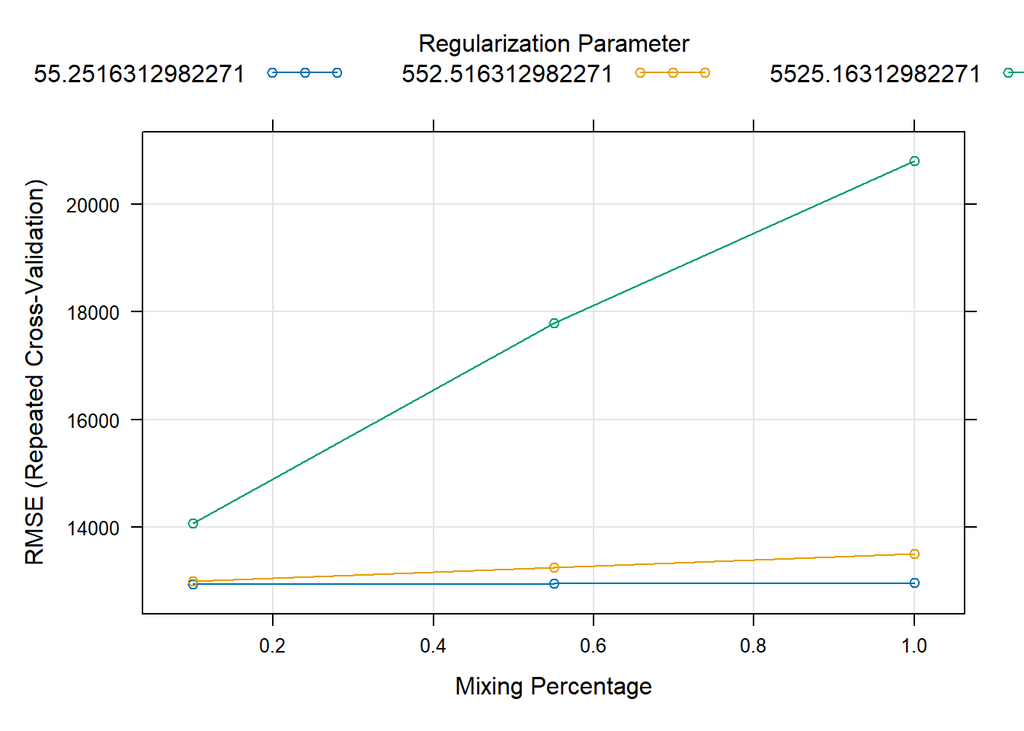

```r
#coefs_noout <- coef(glmnet_noout.fit$finalModel, glmnet_noout.fit$finalModel$lambdaOpt)
#active_predictors_noout <- rownames(coefs_noout)[as.numeric(coefs_noout) != 0]
#active_predictors_noout

#GLMNET_NOOUT ASSUMPTION
##QQ Plot Normal Distribution is violated, the plot this would also apply for the glmnet WITH the outliers
plot(glmnet_noout.fit, which=5)
```

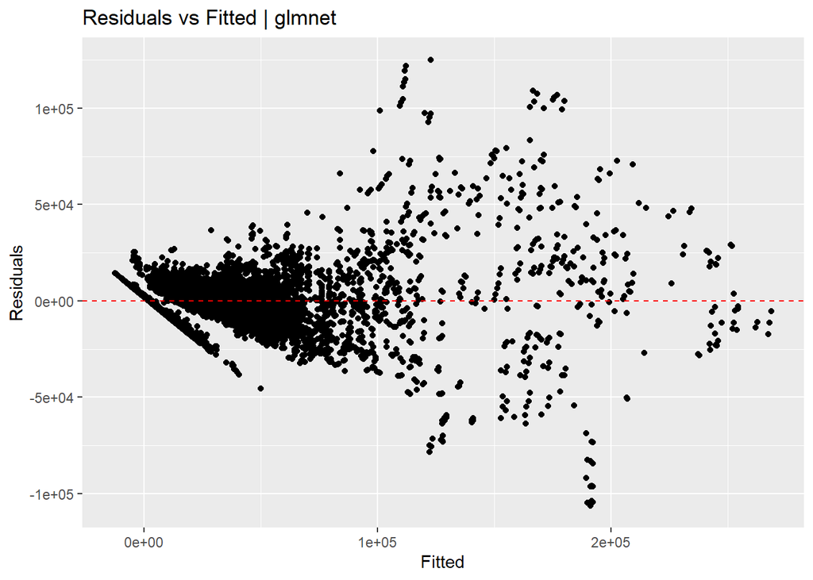

```r
preds_noout <- predict(glmnet_noout.fit, newdata = auto_omit_reduced_no_outliers)
residuals_noout <- auto_omit_reduced_no_outliers$MSRP - preds_noout
df_resid_noout <- data.frame(Fitted = as.numeric(preds_noout), Residuals = as.numeric(residuals_noout))
ggplot(df_resid_noout, aes(x=Fitted, y=Residuals)) +
  geom_point() +
  geom_hline(yintercept=0, linetype="dashed", color="red") +
  labs(title="Residuals vs Fitted | glmnet")
```

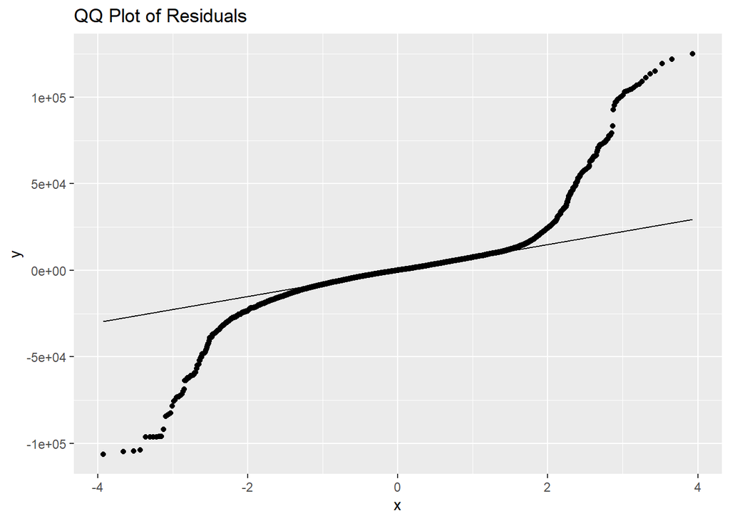

```r
ggplot(data.frame(resid = resid(glmnet_noout.fit)), aes(sample = resid)) +
  stat_qq() +
  stat_qq_line() +
  labs(title="QQ Plot of Residuals")
```

##Log Transforming MSRP We will transform the MSRP to resolve some assumption violations. The outliers are so strong that, we’ve decided to see what it looks like when you transfrom the log transform the msrp

```r
# Full Model (all predictors) -- LOG TRANSFORMATION
full.model_log <- lm(log(MSRP) ~ ., data = auto_omit_reduced)
full.model_noout_log <- lm(log(MSRP) ~ ., data = auto_omit_reduced_no_outliers)

# Null Model (only intercept) -- LOG TRANSFORMATION
null.model_log <- lm(log(MSRP) ~ 1, data = auto_omit_reduced)
null.model_noout_log <- lm(log(MSRP) ~ 1, data = auto_omit_reduced_no_outliers)

# Forward Selection -- LOG TRANSFORMATION
#log(MSRP) ~ Year + Market.Category + Engine.HP + Engine.Fuel.Type + Vehicle.Style + city.mpg + Transmission.Type + Driven_Wheels #-20175.37 (NoOut) -20196.35(FULL)
forward_log <- step(null.model_log, scope = formula(full.model_log), direction = "forward")
```

```
## Start:  AIC=2437.47
## log(MSRP) ~ 1
##
##                     Df Sum of Sq     RSS     AIC
## + Year               1    8573.8  5945.9 -8109.0
## + Engine.HP          1    6708.7  7810.9 -4885.6
## + Market.Category   70    5725.5  8794.2 -3346.7
## + Engine.Fuel.Type   9    4405.5 10114.1 -1816.5
## + Vehicle.Style     15    2365.4 12154.2   366.4
## + Transmission.Type  4    2300.9 12218.8   407.0
## + Driven_Wheels      3    1299.4 13220.2  1335.8
## + city.mpg           1     105.8 14413.9  2353.1
## <none>                           14519.7  2437.5
##
## Step:  AIC=-8109.02
## log(MSRP) ~ Year
##
##                     Df Sum of Sq    RSS      AIC
## + Market.Category   70   2918.24 3027.6 -15943.1
## + Engine.HP          1   2767.72 3178.2 -15507.9
## + Engine.Fuel.Type   9   1893.33 4052.6 -12620.3
## + city.mpg           1   1069.46 4876.4 -10449.8
## + Vehicle.Style     15    833.56 5112.3  -9863.6
## + Driven_Wheels      3    751.44 5194.4  -9699.3
## + Transmission.Type  4    257.80 5688.1  -8624.7
## <none>                           5945.9  -8109.0
##
## Step:  AIC=-15943.14
## log(MSRP) ~ Year + Market.Category
##
##                     Df Sum of Sq    RSS    AIC
## + Engine.HP          1    483.33 2544.3 -17996
## + city.mpg           1    286.08 2741.6 -17114
## + Vehicle.Style     14    269.18 2758.5 -17015
## + Engine.Fuel.Type   9    169.26 2858.4 -16605
## + Transmission.Type  4    152.50 2875.1 -16546
## + Driven_Wheels      3     99.43 2928.2 -16332
## <none>                           3027.6 -15943
##
## Step:  AIC=-17996.05
```

[output cut: 35 more lines]

```
## + Transmission.Type  4    48.119 2113.4 -20132
## + Driven_Wheels      3    12.671 2148.9 -19938
## <none>                           2161.5 -19874
##
## Step:  AIC=-20132.36
## log(MSRP) ~ Year + Market.Category + Engine.HP + Engine.Fuel.Type +
##     Vehicle.Style + city.mpg + Transmission.Type
##
##                 Df Sum of Sq    RSS    AIC
## + Driven_Wheels  3    12.483 2100.9 -20196
## <none>                       2113.4 -20132
##
## Step:  AIC=-20196.35
## log(MSRP) ~ Year + Market.Category + Engine.HP + Engine.Fuel.Type +
##     Vehicle.Style + city.mpg + Transmission.Type + Driven_Wheels
```

```r
forward_noout_log <- step(null.model_noout_log, scope = formula(full.model_noout_log), direction = "forward")
```

```
## Start:  AIC=1747.76
## log(MSRP) ~ 1
##
##                     Df Sum of Sq     RSS     AIC
## + Year               1    8516.4  5062.4 -9790.3
## + Engine.HP          1    5843.3  7735.5 -4831.5
## + Market.Category   69    4867.0  8711.8 -3305.3
## + Engine.Fuel.Type   9    3840.8  9738.0 -2122.9
## + Vehicle.Style     15    2187.9 11390.9  -277.1
## + Transmission.Type  4    2126.3 11452.4  -236.1
## + Driven_Wheels      3    1165.2 12413.5   704.4
## + city.mpg           1      38.7 13540.0  1716.3
## <none>                           13578.8  1747.8
##
## Step:  AIC=-9790.35
## log(MSRP) ~ Year
##
##                     Df Sum of Sq    RSS      AIC
## + Market.Category   69   2135.81 2926.6 -16061.8
## + Engine.HP          1   2086.02 2976.4 -16000.5
## + Engine.Fuel.Type   9   1460.86 3601.5 -13754.6
## + city.mpg           1    832.39 4230.0 -11889.4
## + Vehicle.Style     15    649.56 4412.8 -11366.5
## + Driven_Wheels      3    614.29 4448.1 -11297.4
## + Transmission.Type  4    182.88 4879.5 -10212.7
## <none>                           5062.4  -9790.3
##
## Step:  AIC=-16061.83
## log(MSRP) ~ Year + Market.Category
##
##                     Df Sum of Sq    RSS    AIC
## + Engine.HP          1    428.31 2498.3 -17911
## + city.mpg           1    274.64 2651.9 -17212
## + Vehicle.Style     14    268.37 2658.2 -17159
## + Engine.Fuel.Type   9    166.51 2760.1 -16729
## + Transmission.Type  4    145.29 2781.3 -16649
## + Driven_Wheels      3     97.60 2829.0 -16453
## <none>                           2926.6 -16062
##
## Step:  AIC=-17910.57
```

[output cut: 35 more lines]

```
## + Transmission.Type  4    48.168 2058.2 -20121
## + Driven_Wheels      3    10.518 2095.8 -19911
## <none>                           2106.4 -19858
##
## Step:  AIC=-20120.79
## log(MSRP) ~ Year + Market.Category + Engine.HP + Engine.Fuel.Type +
##     city.mpg + Vehicle.Style + Transmission.Type
##
##                 Df Sum of Sq    RSS    AIC
## + Driven_Wheels  3    10.633 2047.6 -20175
## <none>                       2058.2 -20121
##
## Step:  AIC=-20175.37
## log(MSRP) ~ Year + Market.Category + Engine.HP + Engine.Fuel.Type +
##     city.mpg + Vehicle.Style + Transmission.Type + Driven_Wheels
```

```r
# Backward Elimination -- LOG TRANSFORMATION
#log(MSRP) ~ Year + Engine.Fuel.Type + Engine.HP + Transmission.Type + Driven_Wheels + Market.Category + Vehicle.Style + city.mpg #AIC: -20175.37 (NoOut) -20196.35 (FULL)
backward_log <- step(full.model_log, direction = "backward")
```

```
## Start:  AIC=-20196.35
## log(MSRP) ~ Year + Engine.Fuel.Type + Engine.HP + Transmission.Type +
##     Driven_Wheels + Market.Category + Vehicle.Style + city.mpg
##
##                     Df Sum of Sq    RSS    AIC
## <none>                           2100.9 -20196
## - Driven_Wheels      3     12.48 2113.4 -20132
## - Engine.HP          1     38.04 2139.0 -19986
## - Transmission.Type  4     47.93 2148.9 -19938
## - Vehicle.Style     14    104.71 2205.6 -19650
## - city.mpg           1    113.49 2214.4 -19577
## - Engine.Fuel.Type   9    159.76 2260.7 -19348
## - Market.Category   69    513.54 2614.5 -17751
## - Year               1   2346.96 4447.9 -11336
```

```r
backward_noout_log <- step(full.model_noout_log, direction = "backward")
```

```
## Start:  AIC=-20175.37
## log(MSRP) ~ Year + Engine.Fuel.Type + Engine.HP + Transmission.Type +
##     Driven_Wheels + Market.Category + Vehicle.Style + city.mpg
##
##                     Df Sum of Sq    RSS    AIC
## <none>                           2047.6 -20175
## - Driven_Wheels      3     10.63 2058.2 -20121
## - Engine.HP          1     21.48 2069.1 -20055
## - Transmission.Type  4     48.28 2095.9 -19911
## - Vehicle.Style     14    105.65 2153.2 -19615
## - city.mpg           1    121.31 2168.9 -19504
## - Engine.Fuel.Type   9    161.35 2208.9 -19306
## - Market.Category   68    396.11 2443.7 -18243
## - Year               1   2361.84 4409.4 -11206
```

```r
# Stepwise Selection -- LOG TRANSFORMATION
#log(MSRP) ~ Year + Market.Category + Engine.HP + Engine.Fuel.Type + city.mpg + Vehicle.Style + Transmission.Type + Driven_Wheels #AIC -20175.37(no out) -20196.35 (FULL)
stepwise_log <- step(null.model_log, scope = formula(full.model_log), direction = "both")
```

```
## Start:  AIC=2437.47
## log(MSRP) ~ 1
##
##                     Df Sum of Sq     RSS     AIC
## + Year               1    8573.8  5945.9 -8109.0
## + Engine.HP          1    6708.7  7810.9 -4885.6
## + Market.Category   70    5725.5  8794.2 -3346.7
## + Engine.Fuel.Type   9    4405.5 10114.1 -1816.5
## + Vehicle.Style     15    2365.4 12154.2   366.4
## + Transmission.Type  4    2300.9 12218.8   407.0
## + Driven_Wheels      3    1299.4 13220.2  1335.8
## + city.mpg           1     105.8 14413.9  2353.1
## <none>                           14519.7  2437.5
##
## Step:  AIC=-8109.02
## log(MSRP) ~ Year
##
##                     Df Sum of Sq     RSS      AIC
## + Market.Category   70    2918.2  3027.6 -15943.1
## + Engine.HP          1    2767.7  3178.2 -15507.9
## + Engine.Fuel.Type   9    1893.3  4052.6 -12620.3
## + city.mpg           1    1069.5  4876.4 -10449.8
## + Vehicle.Style     15     833.6  5112.3  -9863.6
## + Driven_Wheels      3     751.4  5194.4  -9699.3
## + Transmission.Type  4     257.8  5688.1  -8624.7
## <none>                            5945.9  -8109.0
## - Year               1    8573.8 14519.7   2437.5
##
## Step:  AIC=-15943.14
## log(MSRP) ~ Year + Market.Category
##
##                     Df Sum of Sq    RSS      AIC
## + Engine.HP          1     483.3 2544.3 -17996.1
## + city.mpg           1     286.1 2741.6 -17113.8
## + Vehicle.Style     14     269.2 2758.5 -17015.3
## + Engine.Fuel.Type   9     169.3 2858.4 -16604.8
## + Transmission.Type  4     152.5 2875.1 -16545.8
## + Driven_Wheels      3      99.4 2928.2 -16331.7
## <none>                           3027.6 -15943.1
## - Market.Category   70    2918.2 5945.9  -8109.0
```

[output cut: 74 more lines]

```
##
## Step:  AIC=-20196.35
## log(MSRP) ~ Year + Market.Category + Engine.HP + Engine.Fuel.Type +
##     Vehicle.Style + city.mpg + Transmission.Type + Driven_Wheels
##
##                     Df Sum of Sq    RSS    AIC
## <none>                           2100.9 -20196
## - Driven_Wheels      3     12.48 2113.4 -20132
## - Engine.HP          1     38.04 2139.0 -19986
## - Transmission.Type  4     47.93 2148.9 -19938
## - Vehicle.Style     14    104.71 2205.6 -19650
## - city.mpg           1    113.49 2214.4 -19577
## - Engine.Fuel.Type   9    159.76 2260.7 -19348
## - Market.Category   69    513.54 2614.5 -17751
## - Year               1   2346.96 4447.9 -11336
```

```r
stepwise_noout_log <- step(null.model_noout_log, scope = formula(full.model_noout_log), direction = "both")
```

```
## Start:  AIC=1747.76
## log(MSRP) ~ 1
##
##                     Df Sum of Sq     RSS     AIC
## + Year               1    8516.4  5062.4 -9790.3
## + Engine.HP          1    5843.3  7735.5 -4831.5
## + Market.Category   69    4867.0  8711.8 -3305.3
## + Engine.Fuel.Type   9    3840.8  9738.0 -2122.9
## + Vehicle.Style     15    2187.9 11390.9  -277.1
## + Transmission.Type  4    2126.3 11452.4  -236.1
## + Driven_Wheels      3    1165.2 12413.5   704.4
## + city.mpg           1      38.7 13540.0  1716.3
## <none>                           13578.8  1747.8
##
## Step:  AIC=-9790.35
## log(MSRP) ~ Year
##
##                     Df Sum of Sq     RSS      AIC
## + Market.Category   69    2135.8  2926.6 -16061.8
## + Engine.HP          1    2086.0  2976.4 -16000.5
## + Engine.Fuel.Type   9    1460.9  3601.5 -13754.6
## + city.mpg           1     832.4  4230.0 -11889.4
## + Vehicle.Style     15     649.6  4412.8 -11366.5
## + Driven_Wheels      3     614.3  4448.1 -11297.4
## + Transmission.Type  4     182.9  4879.5 -10212.7
## <none>                            5062.4  -9790.3
## - Year               1    8516.4 13578.8   1747.8
##
## Step:  AIC=-16061.83
## log(MSRP) ~ Year + Market.Category
##
##                     Df Sum of Sq    RSS      AIC
## + Engine.HP          1     428.3 2498.3 -17910.6
## + city.mpg           1     274.6 2651.9 -17212.4
## + Vehicle.Style     14     268.4 2658.2 -17158.8
## + Engine.Fuel.Type   9     166.5 2760.1 -16729.0
## + Transmission.Type  4     145.3 2781.3 -16649.4
## + Driven_Wheels      3      97.6 2829.0 -16452.5
## <none>                           2926.6 -16061.8
## - Market.Category   69    2135.8 5062.4  -9790.3
```

[output cut: 74 more lines]

```
##
## Step:  AIC=-20175.37
## log(MSRP) ~ Year + Market.Category + Engine.HP + Engine.Fuel.Type +
##     city.mpg + Vehicle.Style + Transmission.Type + Driven_Wheels
##
##                     Df Sum of Sq    RSS    AIC
## <none>                           2047.6 -20175
## - Driven_Wheels      3     10.63 2058.2 -20121
## - Engine.HP          1     21.48 2069.1 -20055
## - Transmission.Type  4     48.28 2095.9 -19911
## - Vehicle.Style     14    105.65 2153.2 -19615
## - city.mpg           1    121.31 2168.9 -19504
## - Engine.Fuel.Type   9    161.35 2208.9 -19306
## - Market.Category   68    396.11 2443.7 -18243
## - Year               1   2361.84 4409.4 -11206
```

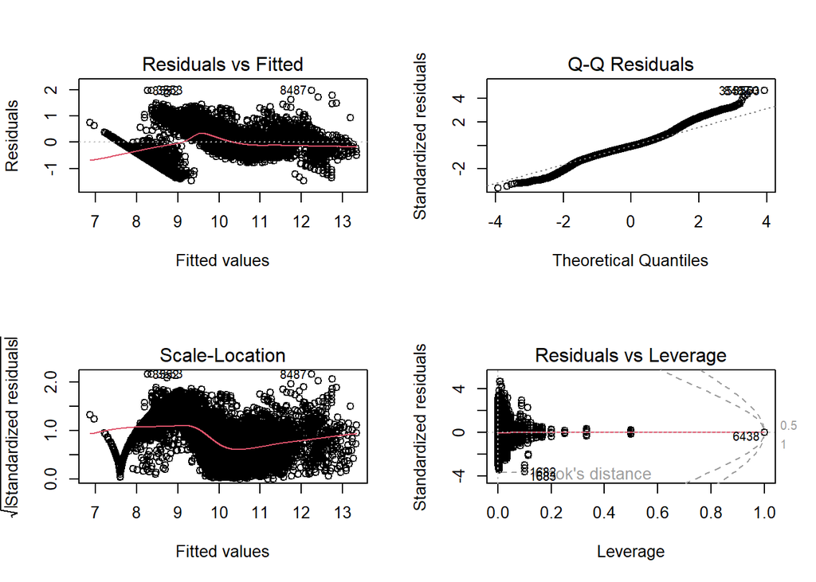

```r
# Assumption Plots for Log-Transformed Models
par(mfrow = c(2, 2))
plot(full.model_log)
```

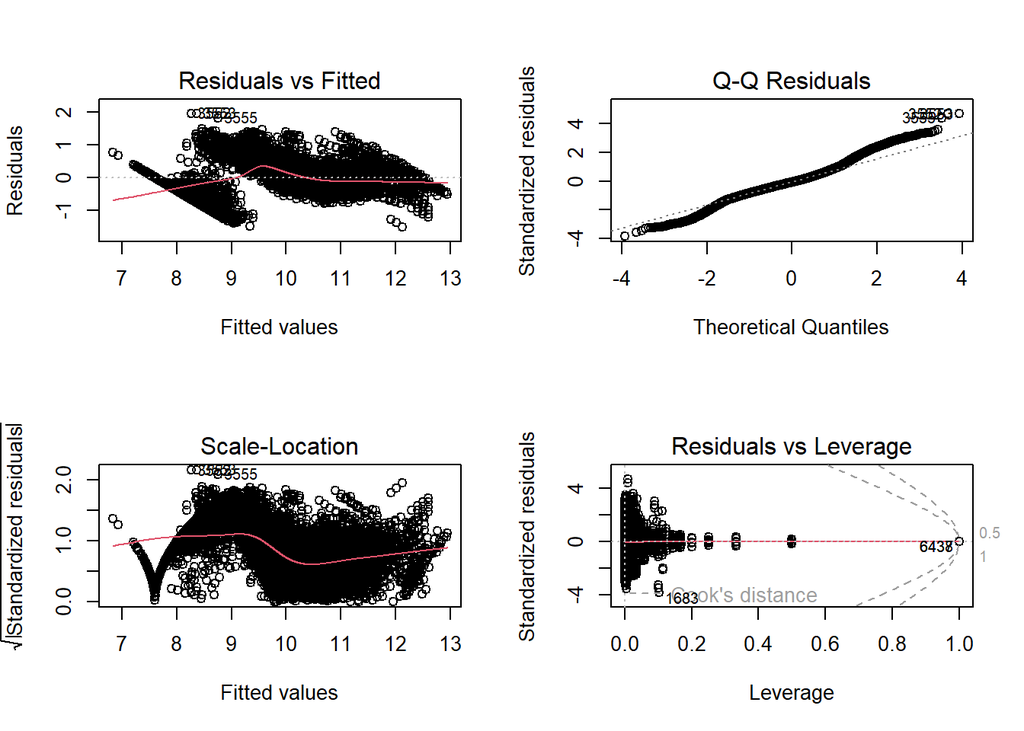

```r
plot(full.model_noout_log)
```

```r
par(mfrow = c(1, 1))

#
# Penalized selection using log(MSRP)
fitControl <- trainControl(method = "repeatedcv", number = 10, repeats = 1)

glmnet_log.fit <- train(log(MSRP) ~ .,
                       data = auto_omit_reduced,
                       method = "glmnet",
                       trControl = fitControl
                      )
opt.pen_log <- glmnet_log.fit$finalModel$lambdaOpt
coef(glmnet_log.fit$finalModel, opt.pen_log)
```

```
## 105 x 1 sparse Matrix of class "dgCMatrix"
##                                                                       s=0.001703724
## (Intercept)                                                           -1.879932e+02
## Year                                                                   9.874984e-02
## Engine.Fuel.Typediesel                                                 3.192124e-01
## Engine.Fuel.Typeelectric                                               3.938697e+00
## Engine.Fuel.Typeflex-fuel (premium unleaded recommended/E85)          -4.828118e-01
## Engine.Fuel.Typeflex-fuel (premium unleaded required/E85)             -7.694330e-02
## Engine.Fuel.Typeflex-fuel (unleaded/E85)                              -3.138453e-01
## Engine.Fuel.Typenatural gas                                            1.317585e-01
## Engine.Fuel.Typepremium unleaded (recommended)                         .
## Engine.Fuel.Typepremium unleaded (required)                            2.715348e-01
## Engine.Fuel.Typeregular unleaded                                      -1.791763e-01
## Engine.HP                                                              1.438159e-03
## Transmission.TypeAUTOMATIC                                             8.408129e-03
## Transmission.TypeDIRECT_DRIVE                                          2.565459e-01
## Transmission.TypeMANUAL                                               -1.718629e-01
## Transmission.TypeUNKNOWN                                              -5.460150e-01
## Driven_Wheelsfour wheel drive                                         -4.271389e-02
## Driven_Wheelsfront wheel drive                                         1.921916e-02
## Driven_Wheelsrear wheel drive                                         -8.958624e-02
## Market.CategoryCrossover,Diesel                                        3.582957e-02
## Market.CategoryCrossover,Exotic,Luxury,High-Performance               -2.220509e-01
## Market.CategoryCrossover,Exotic,Luxury,Performance                    -2.505714e-01
## Market.CategoryCrossover,Factory Tuner,Luxury,High-Performance        -1.259395e-01
## Market.CategoryCrossover,Factory Tuner,Luxury,Performance             -3.065310e-01
## Market.CategoryCrossover,Factory Tuner,Performance                     3.240624e-01
## Market.CategoryCrossover,Flex Fuel                                     1.771805e-01
## Market.CategoryCrossover,Flex Fuel,Luxury                              5.873090e-01
## Market.CategoryCrossover,Flex Fuel,Luxury,Performance                  9.115249e-01
## Market.CategoryCrossover,Flex Fuel,Performance                         .
## Market.CategoryCrossover,Hatchback                                     1.380805e-01
## Market.CategoryCrossover,Hatchback,Factory Tuner,Performance          -2.125783e-01
## Market.CategoryCrossover,Hatchback,Luxury                              2.108248e-01
## Market.CategoryCrossover,Hatchback,Performance                         3.940867e-02
## Market.CategoryCrossover,Hybrid                                        7.410621e-01
## Market.CategoryCrossover,Luxury                                        3.324098e-02
## Market.CategoryCrossover,Luxury,Diesel                                 1.010213e-01
## Market.CategoryCrossover,Luxury,High-Performance                       5.819249e-02
## Market.CategoryCrossover,Luxury,Hybrid                                 6.492851e-01
```

[output cut: 52 more lines]

```
## Vehicle.Style4dr Hatchback                                            -5.225726e-02
## Vehicle.Style4dr SUV                                                   7.382077e-02
## Vehicle.StyleCargo Minivan                                            -4.969659e-02
## Vehicle.StyleCargo Van                                                -5.587364e-01
## Vehicle.StyleConvertible                                               1.737335e-01
## Vehicle.StyleConvertible SUV                                           3.180791e-01
## Vehicle.StyleCoupe                                                    -5.886641e-03
## Vehicle.StyleCrew Cab Pickup                                          -4.341027e-02
## Vehicle.StyleExtended Cab Pickup                                      -1.689271e-01
## Vehicle.StylePassenger Minivan                                         2.157192e-02
## Vehicle.StylePassenger Van                                            -4.296384e-01
## Vehicle.StyleRegular Cab Pickup                                       -2.136468e-01
## Vehicle.StyleSedan                                                    -6.387733e-02
## Vehicle.StyleWagon                                                     7.316463e-02
## city.mpg                                                              -4.152397e-02
```

```r
glmnet_log.fit
```

```
## glmnet
##
## 11815 samples
##     8 predictor
##
## No pre-processing
## Resampling: Cross-Validated (10 fold, repeated 1 times)
## Summary of sample sizes: 10635, 10632, 10634, 10633, 10634, 10633, ...
## Resampling results across tuning parameters:
##
##   alpha  lambda       RMSE       Rsquared   MAE
##   0.10   0.001703724  0.4249672  0.8531162  0.3145599
##   0.10   0.017037236  0.4270627  0.8517973  0.3168958
##   0.10   0.170372361  0.4608661  0.8352666  0.3430747
##   0.55   0.001703724  0.4253652  0.8528387  0.3153302
##   0.55   0.017037236  0.4359187  0.8459220  0.3279541
##   0.55   0.170372361  0.5125693  0.8073515  0.3781407
##   1.00   0.001703724  0.4259364  0.8524504  0.3162866
##   1.00   0.017037236  0.4487053  0.8369999  0.3413623
##   1.00   0.170372361  0.5479752  0.7918850  0.4000800
##
## RMSE was used to select the optimal model using the smallest value.
## The final values used for the model were alpha = 0.1 and lambda = 0.001703724.
```

```r
coefs_log <- coef(glmnet_log.fit$finalModel, glmnet_log.fit$finalModel$lambdaOpt)
active_predictors_log <- rownames(coefs_log)[as.numeric(coefs_log) != 0]
active_predictors_log
```

```
##   [1] "(Intercept)"
##   [2] "Year"
##   [3] "Engine.Fuel.Typediesel"
##   [4] "Engine.Fuel.Typeelectric"
##   [5] "Engine.Fuel.Typeflex-fuel (premium unleaded recommended/E85)"
##   [6] "Engine.Fuel.Typeflex-fuel (premium unleaded required/E85)"
##   [7] "Engine.Fuel.Typeflex-fuel (unleaded/E85)"
##   [8] "Engine.Fuel.Typenatural gas"
##   [9] "Engine.Fuel.Typepremium unleaded (required)"
##  [10] "Engine.Fuel.Typeregular unleaded"
##  [11] "Engine.HP"
##  [12] "Transmission.TypeAUTOMATIC"
##  [13] "Transmission.TypeDIRECT_DRIVE"
##  [14] "Transmission.TypeMANUAL"
##  [15] "Transmission.TypeUNKNOWN"
```

[output cut: 88 more lines]

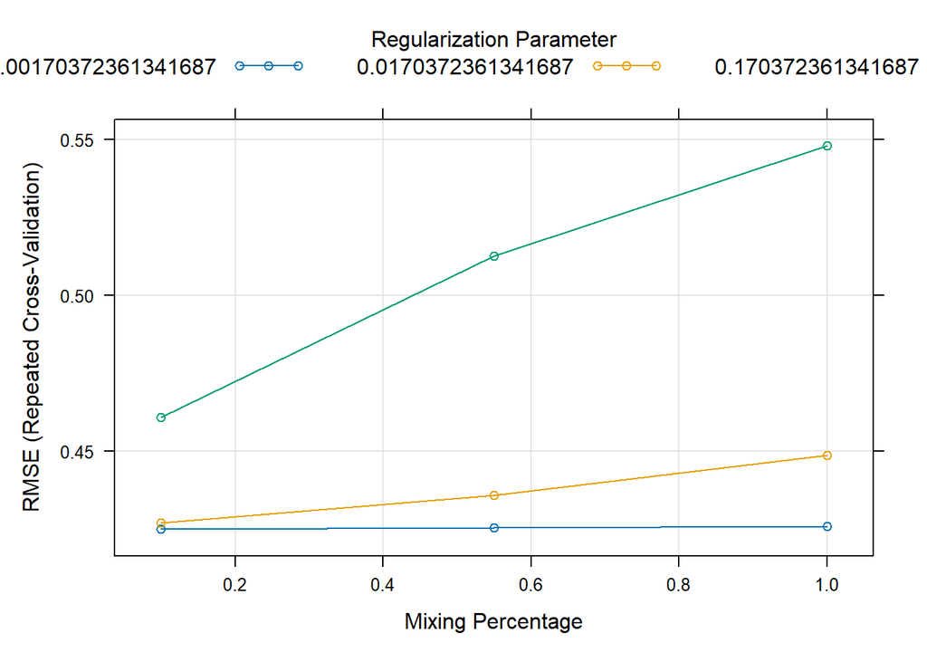

```r
plot(glmnet_log.fit)
```

```r
glmnet_noout_log.fit <- train(log(MSRP) ~ .,
                             data = auto_omit_reduced_no_outliers,
                             method = "glmnet",
                             trControl = fitControl
                            )
opt.pen_noout_log <- glmnet_noout_log.fit$finalModel$lambdaOpt
#coef(glmnet_noout_log.fit$finalModel, opt.pen_noout_log)
glmnet_noout_log.fit
```

```
## glmnet
##
## 11696 samples
##     8 predictor
##
## No pre-processing
## Resampling: Cross-Validated (10 fold, repeated 1 times)
## Summary of sample sizes: 10527, 10527, 10526, 10526, 10527, 10526, ...
## Resampling results across tuning parameters:
##
##   alpha  lambda       RMSE       Rsquared   MAE
##   0.10   0.001706629  0.4213541  0.8469775  0.3127149
##   0.10   0.017066290  0.4236992  0.8454393  0.3150474
##   0.10   0.170662904  0.4584644  0.8274477  0.3413457
##   0.55   0.001706629  0.4218006  0.8466625  0.3135095
##   0.55   0.017066290  0.4328481  0.8390854  0.3259926
##   0.55   0.170662904  0.5022902  0.8051091  0.3739343
##   1.00   0.001706629  0.4223968  0.8462414  0.3144809
##   1.00   0.017066290  0.4459897  0.8294471  0.3395701
##   1.00   0.170662904  0.5372262  0.7888544  0.3978577
##
## RMSE was used to select the optimal model using the smallest value.
## The final values used for the model were alpha = 0.1 and lambda = 0.001706629.
```

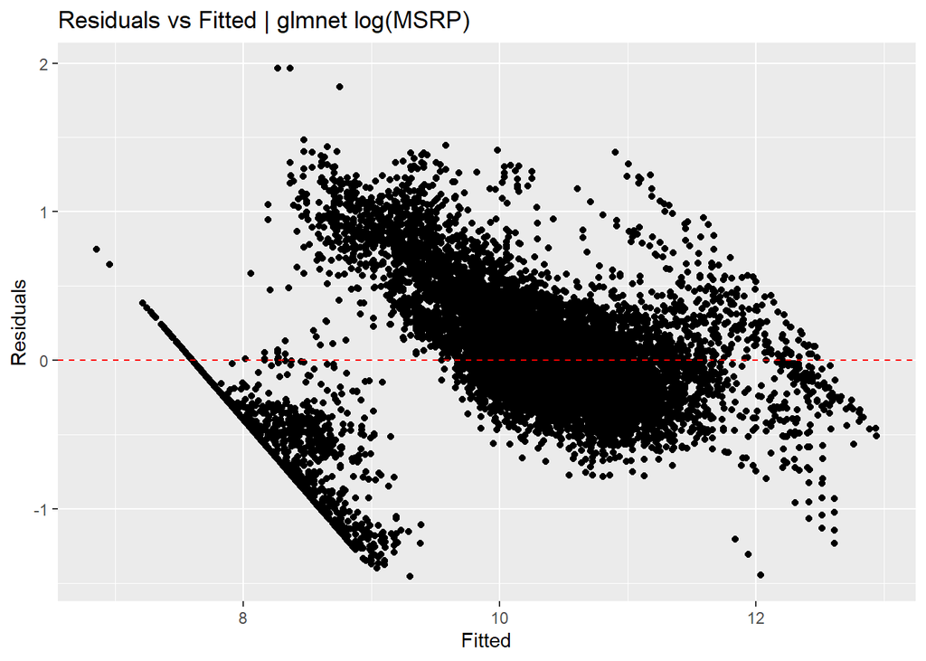

```r
coefs_noout_log <- coef(glmnet_noout_log.fit$finalModel, glmnet_noout_log.fit$finalModel$lambdaOpt)
active_predictors_noout_log <- rownames(coefs_noout_log)[as.numeric(coefs_noout_log) != 0]
#active_predictors_noout_log

# Predict and get residuals for log(MSRP)
preds_noout_log <- predict(glmnet_noout_log.fit, newdata = auto_omit_reduced_no_outliers)
residuals_noout_log <- log(auto_omit_reduced_no_outliers$MSRP) - preds_noout_log
df_resid_noout_log <- data.frame(Fitted = as.numeric(preds_noout_log), Residuals = as.numeric(residuals_noout_log))

# Residuals vs Fitted for log model
library(ggplot2)
ggplot(df_resid_noout_log, aes(x=Fitted, y=Residuals)) +
  geom_point() +
  geom_hline(yintercept=0, linetype="dashed", color="red") +
  labs(title = "Residuals vs Fitted | glmnet log(MSRP)")
```

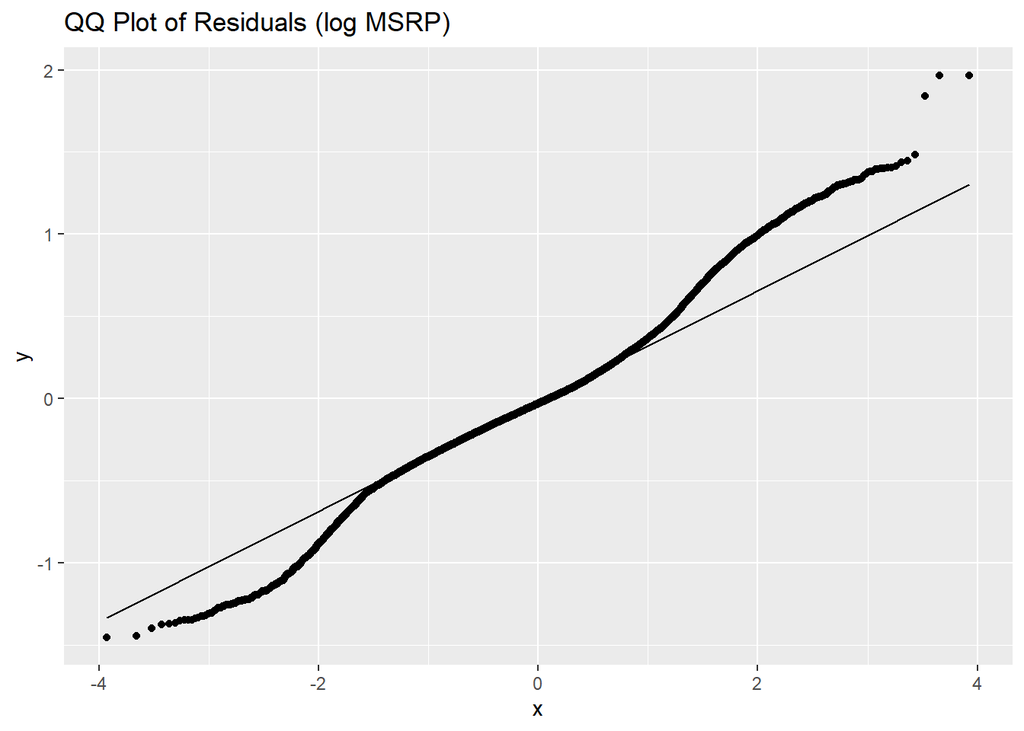

```r
# QQ Plot for log residuals
ggplot(data.frame(resid = residuals_noout_log), aes(sample = resid)) +
  stat_qq() +
  stat_qq_line() +
  labs(title = "QQ Plot of Residuals (log MSRP)")
```

```r
##Summary of coefficients
summary(full.model_noout_log)
```

```
##
## Call:
## lm(formula = log(MSRP) ~ ., data = auto_omit_reduced_no_outliers)
##
## Residuals:
##      Min       1Q   Median       3Q      Max
## -1.52791 -0.24214 -0.03115  0.21098  1.96283
##
## Coefficients: (1 not defined because of singularities)
##                                                                         Estimate
## (Intercept)                                                           -1.928e+02
## Year                                                                   1.014e-01
## Engine.Fuel.Typediesel                                                -1.458e-02
## Engine.Fuel.Typeelectric                                               3.976e+00
## Engine.Fuel.Typeflex-fuel (premium unleaded recommended/E85)          -8.619e-01
## Engine.Fuel.Typeflex-fuel (premium unleaded required/E85)             -4.385e-01
## Engine.Fuel.Typeflex-fuel (unleaded/E85)                              -6.555e-01
## Engine.Fuel.Typenatural gas                                           -2.051e-01
## Engine.Fuel.Typepremium unleaded (recommended)                        -3.335e-01
## Engine.Fuel.Typepremium unleaded (required)                           -5.960e-02
## Engine.Fuel.Typeregular unleaded                                      -5.074e-01
## Engine.HP                                                              1.049e-03
## Transmission.TypeAUTOMATIC                                             2.090e-02
## Transmission.TypeDIRECT_DRIVE                                          2.613e-01
## Transmission.TypeMANUAL                                               -1.626e-01
## Transmission.TypeUNKNOWN                                              -5.406e-01
## Driven_Wheelsfour wheel drive                                         -5.297e-02
## Driven_Wheelsfront wheel drive                                         2.005e-02
## Driven_Wheelsrear wheel drive                                         -9.281e-02
## Market.CategoryCrossover,Diesel                                        6.512e-02
## Market.CategoryCrossover,Exotic,Luxury,High-Performance               -1.775e-01
## Market.CategoryCrossover,Exotic,Luxury,Performance                    -2.368e-01
## Market.CategoryCrossover,Factory Tuner,Luxury,High-Performance        -2.660e-02
## Market.CategoryCrossover,Factory Tuner,Luxury,Performance             -2.662e-01
## Market.CategoryCrossover,Factory Tuner,Performance                     3.625e-01
## Market.CategoryCrossover,Flex Fuel                                     2.143e-01
## Market.CategoryCrossover,Flex Fuel,Luxury                              6.649e-01
## Market.CategoryCrossover,Flex Fuel,Luxury,Performance                  1.046e+00
## Market.CategoryCrossover,Flex Fuel,Performance                         2.637e-02
## Market.CategoryCrossover,Hatchback                                     1.211e-01
```

[output cut: 485 more lines]

```
## Vehicle.StyleCoupe                                                    ***
## Vehicle.StyleCrew Cab Pickup                                          ***
## Vehicle.StyleExtended Cab Pickup                                      ***
## Vehicle.StylePassenger Minivan                                        *
## Vehicle.StylePassenger Van                                            ***
## Vehicle.StyleRegular Cab Pickup                                       ***
## Vehicle.StyleSedan                                                    ***
## Vehicle.StyleWagon
## city.mpg                                                              ***
## ---
## Signif. codes:  0 '***' 0.001 '**' 0.01 '*' 0.05 '.' 0.1 ' ' 1
##
## Residual standard error: 0.4203 on 11593 degrees of freedom
## Multiple R-squared:  0.8492, Adjusted R-squared:  0.8479
## F-statistic: 640.1 on 102 and 11593 DF,  p-value: < 2.2e-16
```

```r
coefs_noout_log
```

```
## 105 x 1 sparse Matrix of class "dgCMatrix"
##                                                                       s=0.001706629
## (Intercept)                                                           -1.911227e+02
## Year                                                                   1.003431e-01
## Engine.Fuel.Typediesel                                                 3.252287e-01
## Engine.Fuel.Typeelectric                                               4.081719e+00
## Engine.Fuel.Typeflex-fuel (premium unleaded recommended/E85)          -4.805289e-01
## Engine.Fuel.Typeflex-fuel (premium unleaded required/E85)             -5.965898e-02
## Engine.Fuel.Typeflex-fuel (unleaded/E85)                              -3.104381e-01
## Engine.Fuel.Typenatural gas                                            1.133117e-01
## Engine.Fuel.Typepremium unleaded (recommended)                         .
## Engine.Fuel.Typepremium unleaded (required)                            2.718279e-01
## Engine.Fuel.Typeregular unleaded                                      -1.785883e-01
## Engine.HP                                                              1.161846e-03
## Transmission.TypeAUTOMATIC                                             2.033196e-02
## Transmission.TypeDIRECT_DRIVE                                          2.796087e-01
## Transmission.TypeMANUAL                                               -1.625931e-01
## Transmission.TypeUNKNOWN                                              -5.358752e-01
## Driven_Wheelsfour wheel drive                                         -3.537262e-02
## Driven_Wheelsfront wheel drive                                         1.874765e-02
## Driven_Wheelsrear wheel drive                                         -8.220076e-02
## Market.CategoryCrossover,Diesel                                        3.531783e-02
## Market.CategoryCrossover,Exotic,Luxury,High-Performance               -1.797591e-01
## Market.CategoryCrossover,Exotic,Luxury,Performance                    -2.300760e-01
## Market.CategoryCrossover,Factory Tuner,Luxury,High-Performance        -5.654481e-02
## Market.CategoryCrossover,Factory Tuner,Luxury,Performance             -2.771924e-01
## Market.CategoryCrossover,Factory Tuner,Performance                     3.396757e-01
## Market.CategoryCrossover,Flex Fuel                                     1.790731e-01
## Market.CategoryCrossover,Flex Fuel,Luxury                              5.976017e-01
## Market.CategoryCrossover,Flex Fuel,Luxury,Performance                  9.507386e-01
## Market.CategoryCrossover,Flex Fuel,Performance                         .
## Market.CategoryCrossover,Hatchback                                     1.478821e-01
## Market.CategoryCrossover,Hatchback,Factory Tuner,Performance          -1.994150e-01
## Market.CategoryCrossover,Hatchback,Luxury                              2.372958e-01
## Market.CategoryCrossover,Hatchback,Performance                         4.892081e-02
## Market.CategoryCrossover,Hybrid                                        7.565772e-01
## Market.CategoryCrossover,Luxury                                        4.448886e-02
## Market.CategoryCrossover,Luxury,Diesel                                 1.018727e-01
## Market.CategoryCrossover,Luxury,High-Performance                       1.116360e-01
## Market.CategoryCrossover,Luxury,Hybrid                                 6.773337e-01
```

[output cut: 52 more lines]

```
## Vehicle.Style4dr Hatchback                                            -5.579847e-02
## Vehicle.Style4dr SUV                                                   7.677713e-02
## Vehicle.StyleCargo Minivan                                            -6.224469e-02
## Vehicle.StyleCargo Van                                                -5.677475e-01
## Vehicle.StyleConvertible                                               1.695305e-01
## Vehicle.StyleConvertible SUV                                           3.080196e-01
## Vehicle.StyleCoupe                                                    -1.095667e-02
## Vehicle.StyleCrew Cab Pickup                                          -3.888601e-02
## Vehicle.StyleExtended Cab Pickup                                      -1.708185e-01
## Vehicle.StylePassenger Minivan                                         2.137601e-02
## Vehicle.StylePassenger Van                                            -4.405797e-01
## Vehicle.StyleRegular Cab Pickup                                       -2.168779e-01
## Vehicle.StyleSedan                                                    -6.607978e-02
## Vehicle.StyleWagon                                                     6.990377e-02
## city.mpg                                                              -4.327424e-02
```

#Objective 2 Complex MLR and Non-Parametric ##EDA for Non-Parametric model #Adding interactions Engine.hp*Vehicle.Style, Engine.HP*Transmission.Type, city.mpg*Engine.Fuel.Type, Engine.hp^2, and city.mpg^2

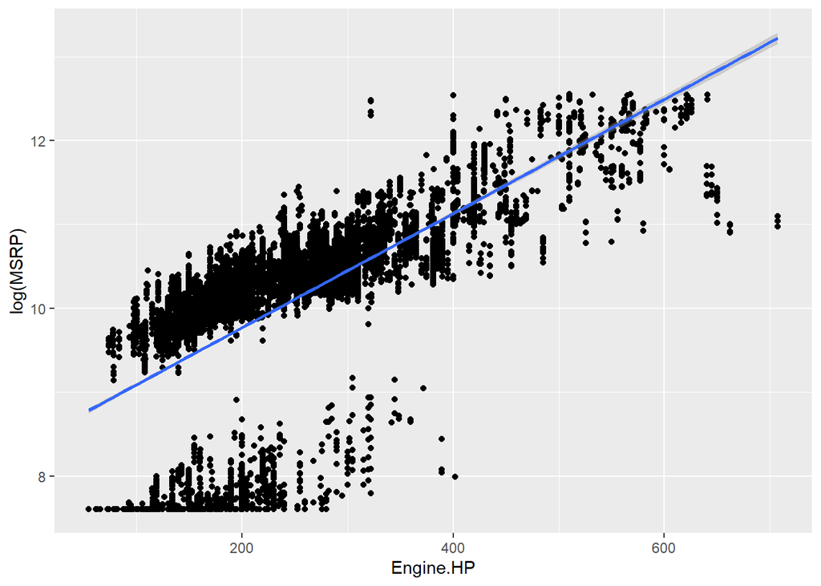

```r
ggplot(auto_omit_reduced_no_outliers, aes(x=Engine.HP, y=log(MSRP))) +
  geom_point() +
  geom_smooth(method='lm')
```

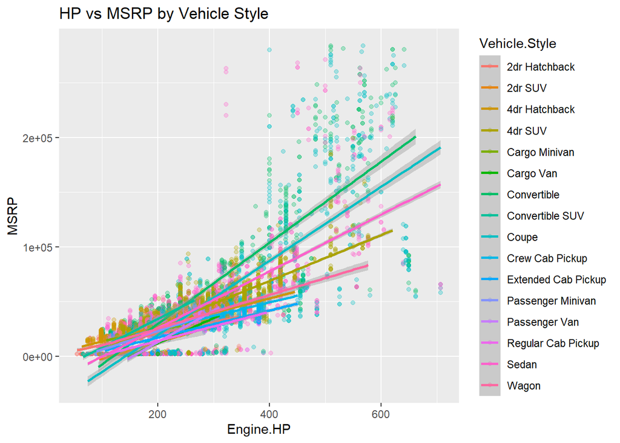

```r
#Evidence of Interaction HP and Vehicle Style
ggplot(auto_omit_reduced_no_outliers, aes(x = Engine.HP, y = MSRP, color = Vehicle.Style)) +
  geom_point(alpha=0.3) +
  geom_smooth(method = "lm") +
  labs(title = "HP vs MSRP by Vehicle Style")
```